pie 차트는 다른 커널을 참고해서 차트 만드는 코드를 가져왔습니다...!

```python
import pandas as pd
import numpy as np
import seaborn as sns
import matplotlib.pyplot as plt
```

# 1. departments 파일

```python
departments = pd.read_csv('departments.csv')
```

```python
departments
```

|  | department_id | department |
| --- | --- | --- |
| 0 | 1 | frozen |
| 1 | 2 | other |
| 2 | 3 | bakery |
| 3 | 4 | produce |
| 4 | 5 | alcohol |
| 5 | 6 | international |
| 6 | 7 | beverages |
| 7 | 8 | pets |
| 8 | 9 | dry goods pasta |
| 9 | 10 | bulk |
| 10 | 11 | personal care |
| 11 | 12 | meat seafood |
| 12 | 13 | pantry |
| 13 | 14 | breakfast |
| 14 | 15 | canned goods |
| 15 | 16 | dairy eggs |
| 16 | 17 | household |
| 17 | 18 | babies |
| 18 | 19 | snacks |
| 19 | 20 | deli |
| 20 | 21 | missing |

```python
dep['department'].unique()
```

```
array(['frozen', 'other', 'bakery', 'produce', 'alcohol', 'international',
       'beverages', 'pets', 'dry goods pasta', 'bulk', 'personal care',
       'meat seafood', 'pantry', 'breakfast', 'canned goods', 'dairy eggs',
       'household', 'babies', 'snacks', 'deli', 'missing'], dtype=object)
```

department는 상품 분류. missing은 결측치로 예상됨

# 2. aisles 파일

```python
aisles = pd.read_csv('aisles.csv')
```

```python
len(aisles['aisle'].unique())
```

```
134
```

```python
aisles
```

|  | aisle_id | aisle |
| --- | --- | --- |
| 0 | 1 | prepared soups salads |
| 1 | 2 | specialty cheeses |
| 2 | 3 | energy granola bars |
| 3 | 4 | instant foods |
| 4 | 5 | marinades meat preparation |
| 5 | 6 | other |
| 6 | 7 | packaged meat |
| 7 | 8 | bakery desserts |
| 8 | 9 | pasta sauce |
| 9 | 10 | kitchen supplies |
| 10 | 11 | cold flu allergy |
| 11 | 12 | fresh pasta |
| 12 | 13 | prepared meals |
| 13 | 14 | tofu meat alternatives |
| 14 | 15 | packaged seafood |
| 15 | 16 | fresh herbs |
| 16 | 17 | baking ingredients |
| 17 | 18 | bulk dried fruits vegetables |
| 18 | 19 | oils vinegars |
| 19 | 20 | oral hygiene |
| 20 | 21 | packaged cheese |
| 21 | 22 | hair care |
| 22 | 23 | popcorn jerky |
| 23 | 24 | fresh fruits |
| 24 | 25 | soap |
| 25 | 26 | coffee |
| 26 | 27 | beers coolers |
| 27 | 28 | red wines |
| 28 | 29 | honeys syrups nectars |
| 29 | 30 | latino foods |
| ... | ... | ... |
| 104 | 105 | doughs gelatins bake mixes |
| 105 | 106 | hot dogs bacon sausage |
| 106 | 107 | chips pretzels |
| 107 | 108 | other creams cheeses |
| 108 | 109 | skin care |
| 109 | 110 | pickled goods olives |
| 110 | 111 | plates bowls cups flatware |
| 111 | 112 | bread |
| 112 | 113 | frozen juice |
| 113 | 114 | cleaning products |
| 114 | 115 | water seltzer sparkling water |
| 115 | 116 | frozen produce |
| 116 | 117 | nuts seeds dried fruit |
| 117 | 118 | first aid |
| 118 | 119 | frozen dessert |
| 119 | 120 | yogurt |
| 120 | 121 | cereal |
| 121 | 122 | meat counter |
| 122 | 123 | packaged vegetables fruits |
| 123 | 124 | spirits |
| 124 | 125 | trail mix snack mix |
| 125 | 126 | feminine care |
| 126 | 127 | body lotions soap |
| 127 | 128 | tortillas flat bread |
| 128 | 129 | frozen appetizers sides |
| 129 | 130 | hot cereal pancake mixes |
| 130 | 131 | dry pasta |
| 131 | 132 | beauty |
| 132 | 133 | muscles joints pain relief |
| 133 | 134 | specialty wines champagnes |

134 rows × 2 columns

departments보다 더 세부적인 품목

# 3. products

```python
products = pd.read_csv('products.csv')
```

```python
products
```

|  | product_id | product_name | aisle_id | department_id |
| --- | --- | --- | --- | --- |
| 0 | 1 | Chocolate Sandwich Cookies | 61 | 19 |
| 1 | 2 | All-Seasons Salt | 104 | 13 |
| 2 | 3 | Robust Golden Unsweetened Oolong Tea | 94 | 7 |
| 3 | 4 | Smart Ones Classic Favorites Mini Rigatoni Wit... | 38 | 1 |
| 4 | 5 | Green Chile Anytime Sauce | 5 | 13 |
| 5 | 6 | Dry Nose Oil | 11 | 11 |
| 6 | 7 | Pure Coconut Water With Orange | 98 | 7 |
| 7 | 8 | Cut Russet Potatoes Steam N' Mash | 116 | 1 |
| 8 | 9 | Light Strawberry Blueberry Yogurt | 120 | 16 |
| 9 | 10 | Sparkling Orange Juice & Prickly Pear Beverage | 115 | 7 |
| 10 | 11 | Peach Mango Juice | 31 | 7 |
| 11 | 12 | Chocolate Fudge Layer Cake | 119 | 1 |
| 12 | 13 | Saline Nasal Mist | 11 | 11 |
| 13 | 14 | Fresh Scent Dishwasher Cleaner | 74 | 17 |
| 14 | 15 | Overnight Diapers Size 6 | 56 | 18 |
| 15 | 16 | Mint Chocolate Flavored Syrup | 103 | 19 |
| 16 | 17 | Rendered Duck Fat | 35 | 12 |
| 17 | 18 | Pizza for One Suprema Frozen Pizza | 79 | 1 |
| 18 | 19 | Gluten Free Quinoa Three Cheese & Mushroom Blend | 63 | 9 |
| 19 | 20 | Pomegranate Cranberry & Aloe Vera Enrich Drink | 98 | 7 |
| 20 | 21 | Small & Medium Dental Dog Treats | 40 | 8 |
| 21 | 22 | Fresh Breath Oral Rinse Mild Mint | 20 | 11 |
| 22 | 23 | Organic Turkey Burgers | 49 | 12 |
| 23 | 24 | Tri-Vi-Sol® Vitamins A-C-and D Supplement Drop... | 47 | 11 |
| 24 | 25 | Salted Caramel Lean Protein & Fiber Bar | 3 | 19 |
| 25 | 26 | Fancy Feast Trout Feast Flaked Wet Cat Food | 41 | 8 |
| 26 | 27 | Complete Spring Water Foaming Antibacterial Ha... | 127 | 11 |
| 27 | 28 | Wheat Chex Cereal | 121 | 14 |
| 28 | 29 | Fresh Cut Golden Sweet No Salt Added Whole Ker... | 81 | 15 |
| 29 | 30 | Three Cheese Ziti, Marinara with Meatballs | 38 | 1 |
| ... | ... | ... | ... | ... |
| 76762 | 49659 | Organic Creamed Coconut | 17 | 13 |
| 76763 | 49660 | Professionals Sleek Shampoo | 22 | 11 |
| 76764 | 49661 | Porto | 134 | 5 |
| 76765 | 49662 | Bacon Cheddar Pretzel Pieces | 107 | 19 |
| 76766 | 49663 | Ultra Protein Power Crunch Peanut Butter N' Ho... | 57 | 14 |
| 76767 | 49664 | Lemon Cayenne Drinking Vinegar | 100 | 21 |
| 76768 | 49665 | Super Dark Coconut Ash & Banana Chocolate Bar | 45 | 19 |
| 76769 | 49666 | Ginger Snaps Snacking Cookies | 61 | 19 |
| 76770 | 49667 | Enchilada with Spanish Rice & Beans Meal | 38 | 1 |
| 76771 | 49668 | Apple Cinnamon Scented Candles | 101 | 17 |
| 76772 | 49669 | K Cup Dark Blend | 100 | 21 |
| 76773 | 49670 | Beef Summer Sausage | 106 | 12 |
| 76774 | 49671 | Milk Chocolate Drops | 45 | 19 |
| 76775 | 49672 | Cafe Mocha K-Cup Packs | 26 | 7 |
| 76776 | 49673 | Stone Baked Multi Grain Artisan Rolls | 129 | 1 |
| 76777 | 49674 | Frozen Greek Yogurt Bars Chocolate Chip | 37 | 1 |
| 76778 | 49675 | Cinnamon Dolce Keurig Brewed K Cups | 26 | 7 |
| 76779 | 49676 | Ultra Red Energy Drink | 64 | 7 |
| 76780 | 49677 | Thick & Chunky Sloppy Joe Sauce | 59 | 15 |
| 76781 | 49678 | Large Chicken & Cheese Taquitos | 129 | 1 |
| 76782 | 49679 | Famous Chocolate Wafers | 61 | 19 |
| 76783 | 49680 | All Natural Creamy Caesar Dressing | 89 | 13 |
| 76784 | 49681 | Spaghetti with Meatballs and Sauce Meal | 38 | 1 |
| 76785 | 49682 | California Limeade | 98 | 7 |
| 76786 | 49683 | Cucumber Kirby | 83 | 4 |
| 76787 | 49684 | Vodka, Triple Distilled, Twist of Vanilla | 124 | 5 |
| 76788 | 49685 | En Croute Roast Hazelnut Cranberry | 42 | 1 |
| 76789 | 49686 | Artisan Baguette | 112 | 3 |
| 76790 | 49687 | Smartblend Healthy Metabolism Dry Cat Food | 41 | 8 |
| 76791 | 49688 | Fresh Foaming Cleanser | 73 | 11 |

76792 rows × 4 columns

각 제품들에 대한 설명. aisle id와 department id포함

## 3-1. product, aisles, departments 합치기

```python
merged_prod_ais=pd.merge(products, aisles, on='aisle_id', how='left')
```

```python
merged_prod_ais_dep = pd.merge(merged_prod_ais, departments, on='department_id', how='left')
```

```python
merged_prod_ais_dep
```

|  | product_id | product_name | aisle_id | department_id | aisle | department |
| --- | --- | --- | --- | --- | --- | --- |
| 0 | 1 | Chocolate Sandwich Cookies | 61 | 19 | cookies cakes | snacks |
| 1 | 2 | All-Seasons Salt | 104 | 13 | spices seasonings | pantry |
| 2 | 3 | Robust Golden Unsweetened Oolong Tea | 94 | 7 | tea | beverages |
| 3 | 4 | Smart Ones Classic Favorites Mini Rigatoni Wit... | 38 | 1 | frozen meals | frozen |
| 4 | 5 | Green Chile Anytime Sauce | 5 | 13 | marinades meat preparation | pantry |
| 5 | 6 | Dry Nose Oil | 11 | 11 | cold flu allergy | personal care |
| 6 | 7 | Pure Coconut Water With Orange | 98 | 7 | juice nectars | beverages |
| 7 | 8 | Cut Russet Potatoes Steam N' Mash | 116 | 1 | frozen produce | frozen |
| 8 | 9 | Light Strawberry Blueberry Yogurt | 120 | 16 | yogurt | dairy eggs |
| 9 | 10 | Sparkling Orange Juice & Prickly Pear Beverage | 115 | 7 | water seltzer sparkling water | beverages |
| 10 | 11 | Peach Mango Juice | 31 | 7 | refrigerated | beverages |
| 11 | 12 | Chocolate Fudge Layer Cake | 119 | 1 | frozen dessert | frozen |
| 12 | 13 | Saline Nasal Mist | 11 | 11 | cold flu allergy | personal care |
| 13 | 14 | Fresh Scent Dishwasher Cleaner | 74 | 17 | dish detergents | household |
| 14 | 15 | Overnight Diapers Size 6 | 56 | 18 | diapers wipes | babies |
| 15 | 16 | Mint Chocolate Flavored Syrup | 103 | 19 | ice cream toppings | snacks |
| 16 | 17 | Rendered Duck Fat | 35 | 12 | poultry counter | meat seafood |
| 17 | 18 | Pizza for One Suprema Frozen Pizza | 79 | 1 | frozen pizza | frozen |
| 18 | 19 | Gluten Free Quinoa Three Cheese & Mushroom Blend | 63 | 9 | grains rice dried goods | dry goods pasta |
| 19 | 20 | Pomegranate Cranberry & Aloe Vera Enrich Drink | 98 | 7 | juice nectars | beverages |
| 20 | 21 | Small & Medium Dental Dog Treats | 40 | 8 | dog food care | pets |
| 21 | 22 | Fresh Breath Oral Rinse Mild Mint | 20 | 11 | oral hygiene | personal care |
| 22 | 23 | Organic Turkey Burgers | 49 | 12 | packaged poultry | meat seafood |
| 23 | 24 | Tri-Vi-Sol® Vitamins A-C-and D Supplement Drop... | 47 | 11 | vitamins supplements | personal care |
| 24 | 25 | Salted Caramel Lean Protein & Fiber Bar | 3 | 19 | energy granola bars | snacks |
| 25 | 26 | Fancy Feast Trout Feast Flaked Wet Cat Food | 41 | 8 | cat food care | pets |
| 26 | 27 | Complete Spring Water Foaming Antibacterial Ha... | 127 | 11 | body lotions soap | personal care |
| 27 | 28 | Wheat Chex Cereal | 121 | 14 | cereal | breakfast |
| 28 | 29 | Fresh Cut Golden Sweet No Salt Added Whole Ker... | 81 | 15 | canned jarred vegetables | canned goods |
| 29 | 30 | Three Cheese Ziti, Marinara with Meatballs | 38 | 1 | frozen meals | frozen |
| ... | ... | ... | ... | ... | ... | ... |
| 76762 | 49659 | Organic Creamed Coconut | 17 | 13 | baking ingredients | pantry |
| 76763 | 49660 | Professionals Sleek Shampoo | 22 | 11 | hair care | personal care |
| 76764 | 49661 | Porto | 134 | 5 | specialty wines champagnes | alcohol |
| 76765 | 49662 | Bacon Cheddar Pretzel Pieces | 107 | 19 | chips pretzels | snacks |
| 76766 | 49663 | Ultra Protein Power Crunch Peanut Butter N' Ho... | 57 | 14 | granola | breakfast |
| 76767 | 49664 | Lemon Cayenne Drinking Vinegar | 100 | 21 | missing | missing |
| 76768 | 49665 | Super Dark Coconut Ash & Banana Chocolate Bar | 45 | 19 | candy chocolate | snacks |
| 76769 | 49666 | Ginger Snaps Snacking Cookies | 61 | 19 | cookies cakes | snacks |
| 76770 | 49667 | Enchilada with Spanish Rice & Beans Meal | 38 | 1 | frozen meals | frozen |
| 76771 | 49668 | Apple Cinnamon Scented Candles | 101 | 17 | air fresheners candles | household |
| 76772 | 49669 | K Cup Dark Blend | 100 | 21 | missing | missing |
| 76773 | 49670 | Beef Summer Sausage | 106 | 12 | hot dogs bacon sausage | meat seafood |
| 76774 | 49671 | Milk Chocolate Drops | 45 | 19 | candy chocolate | snacks |
| 76775 | 49672 | Cafe Mocha K-Cup Packs | 26 | 7 | coffee | beverages |
| 76776 | 49673 | Stone Baked Multi Grain Artisan Rolls | 129 | 1 | frozen appetizers sides | frozen |
| 76777 | 49674 | Frozen Greek Yogurt Bars Chocolate Chip | 37 | 1 | ice cream ice | frozen |
| 76778 | 49675 | Cinnamon Dolce Keurig Brewed K Cups | 26 | 7 | coffee | beverages |
| 76779 | 49676 | Ultra Red Energy Drink | 64 | 7 | energy sports drinks | beverages |
| 76780 | 49677 | Thick & Chunky Sloppy Joe Sauce | 59 | 15 | canned meals beans | canned goods |
| 76781 | 49678 | Large Chicken & Cheese Taquitos | 129 | 1 | frozen appetizers sides | frozen |
| 76782 | 49679 | Famous Chocolate Wafers | 61 | 19 | cookies cakes | snacks |
| 76783 | 49680 | All Natural Creamy Caesar Dressing | 89 | 13 | salad dressing toppings | pantry |
| 76784 | 49681 | Spaghetti with Meatballs and Sauce Meal | 38 | 1 | frozen meals | frozen |
| 76785 | 49682 | California Limeade | 98 | 7 | juice nectars | beverages |
| 76786 | 49683 | Cucumber Kirby | 83 | 4 | fresh vegetables | produce |
| 76787 | 49684 | Vodka, Triple Distilled, Twist of Vanilla | 124 | 5 | spirits | alcohol |
| 76788 | 49685 | En Croute Roast Hazelnut Cranberry | 42 | 1 | frozen vegan vegetarian | frozen |
| 76789 | 49686 | Artisan Baguette | 112 | 3 | bread | bakery |
| 76790 | 49687 | Smartblend Healthy Metabolism Dry Cat Food | 41 | 8 | cat food care | pets |
| 76791 | 49688 | Fresh Foaming Cleanser | 73 | 11 | facial care | personal care |

76792 rows × 6 columns

```python
merged_prod_ais_dep
```

[output not shown]

76792 rows × 6 columns

## 3-2. department 별 제품 개수

```python
merged_prod_ais_dep.groupby('department').size().sort_values(ascending=False)
```

```
department
personal care      10116
snacks              9693
pantry              8369
beverages           6709
frozen              6187
dairy eggs          5328
household           4709
canned goods        3199
dry goods pasta     2886
produce             2579
bakery              2381
deli                2025
missing             1956
breakfast           1753
international       1740
babies              1672
alcohol             1639
pets                1502
meat seafood        1434
other                857
bulk                  58
dtype: int64
```

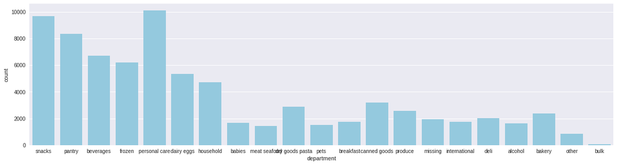

```python
fig, ax = plt.subplots(figsize=(20,5))
sns.countplot(x="department", data=merged_prod_ais_dep, color='skyblue')
```

#### top 10만 볼까?

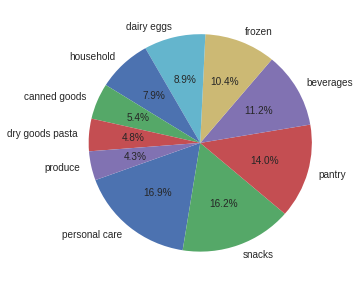

```python
plt.figure(figsize=(5,5))
temp2 = merged_prod_ais_dep['department'].value_counts().head(10)
labels = (np.array(temp2.index))
sizes = (np.array((temp2 / temp2.sum())*100))
plt.pie(sizes, labels=labels,
        autopct='%1.1f%%', startangle=200)
plt.show()
```

## 3-3. aisle 별 제품 개수

```python
merged_prod_ais_dep.groupby('aisle').size().sort_values(ascending=False)
```

```
aisle
missing                          1956
candy chocolate                  1952
ice cream ice                    1678
vitamins supplements             1595
yogurt                           1584
chips pretzels                   1563
packaged cheese                  1384
tea                              1373
frozen meals                     1370
cookies cakes                    1345
energy granola bars              1266
hair care                        1256
spices seasonings                1251
juice nectars                    1231
crackers                         1150
baby food formula                1126
soup broth bouillon              1096
coffee                           1048
refrigerated                     1025
cleaning products                1003
baking ingredients                978
packaged vegetables fruits        936
asian foods                       923
nuts seeds dried fruit            887
salad dressing toppings           876
fresh vegetables                  874
oral hygiene                      866
bread                             859
other                             857
instant foods                     842
                                 ...
kosher foods                      252
tofu meat alternatives            251
cream                             250
butter                            238
white wines                       236
prepared soups salads             233
fresh pasta                       197
baby bath body care               196
```

[output cut: 8 more lines]

```
specialty wines champagnes        150
refrigerated pudding desserts     146
poultry counter                   136
ice cream toppings                129
frozen breads doughs              127
fresh herbs                       126
packaged seafood                  125
trail mix snack mix               105
seafood counter                    84
frozen juice                       72
baby accessories                   65
packaged produce                   45
bulk grains rice dried goods       41
bulk dried fruits vegetables       17
dtype: int64
```

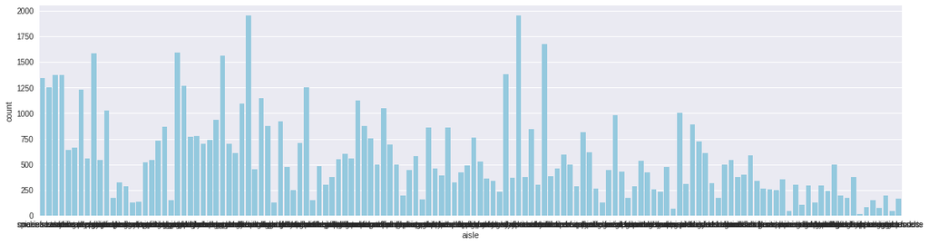

```python
fig, ax = plt.subplots(figsize=(20,5))
sns.countplot(x="aisle", data=merged_prod_ais_dep, color='skyblue')
```

#### bar graph로 나타내니 aisle이 너무 많아서 읽을 수 없음 --> top 10만 볼까?

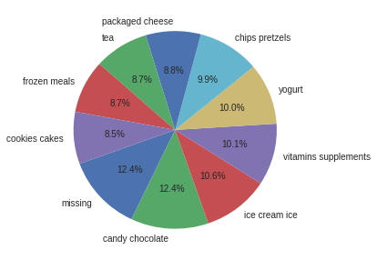

```python
plt.figure(figsize=(5,5))
temp2 = merged_prod_ais_dep['aisle'].value_counts().head(10)
labels = (np.array(temp2.index))
sizes = (np.array((temp2 / temp2.sum())*100))
plt.pie(sizes, labels=labels,
        autopct='%1.1f%%', startangle=200)
plt.show()
```

```python
import cufflinks as cf
cf.go_offline()
```

```python
temp=pd.DataFrame(merged_prod_ais_dep.groupby(['aisle']).size().sort_values(ascending=False)).head(10)
temp
```

| aisle | 0 |
| --- | --- |
| missing | 1956 |
| candy chocolate | 1952 |
| ice cream ice | 1678 |
| vitamins supplements | 1595 |
| yogurt | 1584 |
| chips pretzels | 1563 |
| packaged cheese | 1384 |
| tea | 1373 |
| frozen meals | 1370 |
| cookies cakes | 1345 |

상대적인 숫자를 보기에 pie chart가 더 낫다 (커프링스 때매 늦어져서 그래프 위에 데이터프레임 가지고 바그래프 그렸는데 지웠어요..)

- department: personal care가 제품 개수가 제일 많다
- aisle: missing이 제일 많다 --> missing이 결측치를 가리키는 말이라고 생각했는데, missing aisle에 해당하는 제품 개수가 많으므로 없애면 안된다

# 4. orders

```python
orders=pd.read_csv('orders.csv')
```

```python
orders
```

|  | order_id | user_id | eval_set | order_number | order_dow | order_hour_of_day | days_since_prior_order |
| --- | --- | --- | --- | --- | --- | --- | --- |
| 0 | 2539329 | 1 | prior | 1 | 2 | 8 | NaN |
| 1 | 2398795 | 1 | prior | 2 | 3 | 7 | 15.0 |
| 2 | 473747 | 1 | prior | 3 | 3 | 12 | 21.0 |
| 3 | 2254736 | 1 | prior | 4 | 4 | 7 | 29.0 |
| 4 | 431534 | 1 | prior | 5 | 4 | 15 | 28.0 |
| 5 | 3367565 | 1 | prior | 6 | 2 | 7 | 19.0 |
| 6 | 550135 | 1 | prior | 7 | 1 | 9 | 20.0 |
| 7 | 3108588 | 1 | prior | 8 | 1 | 14 | 14.0 |
| 8 | 2295261 | 1 | prior | 9 | 1 | 16 | 0.0 |
| 9 | 2550362 | 1 | prior | 10 | 4 | 8 | 30.0 |
| 10 | 1187899 | 1 | train | 11 | 4 | 8 | 14.0 |
| 11 | 2168274 | 2 | prior | 1 | 2 | 11 | NaN |
| 12 | 1501582 | 2 | prior | 2 | 5 | 10 | 10.0 |
| 13 | 1901567 | 2 | prior | 3 | 1 | 10 | 3.0 |
| 14 | 738281 | 2 | prior | 4 | 2 | 10 | 8.0 |
| 15 | 1673511 | 2 | prior | 5 | 3 | 11 | 8.0 |
| 16 | 1199898 | 2 | prior | 6 | 2 | 9 | 13.0 |
| 17 | 3194192 | 2 | prior | 7 | 2 | 12 | 14.0 |
| 18 | 788338 | 2 | prior | 8 | 1 | 15 | 27.0 |
| 19 | 1718559 | 2 | prior | 9 | 2 | 9 | 8.0 |
| 20 | 1447487 | 2 | prior | 10 | 1 | 11 | 6.0 |
| 21 | 1402090 | 2 | prior | 11 | 1 | 10 | 30.0 |
| 22 | 3186735 | 2 | prior | 12 | 1 | 9 | 28.0 |
| 23 | 3268552 | 2 | prior | 13 | 4 | 11 | 30.0 |
| 24 | 839880 | 2 | prior | 14 | 3 | 10 | 13.0 |
| 25 | 1492625 | 2 | train | 15 | 1 | 11 | 30.0 |
| 26 | 1374495 | 3 | prior | 1 | 1 | 14 | NaN |
| 27 | 444309 | 3 | prior | 2 | 3 | 19 | 9.0 |
| 28 | 3002854 | 3 | prior | 3 | 3 | 16 | 21.0 |
| 29 | 2037211 | 3 | prior | 4 | 2 | 18 | 20.0 |
| ... | ... | ... | ... | ... | ... | ... | ... |
| 3421053 | 2789700 | 206208 | prior | 35 | 3 | 22 | 4.0 |
| 3421054 | 844592 | 206208 | prior | 36 | 6 | 15 | 10.0 |
| 3421055 | 1541132 | 206208 | prior | 37 | 2 | 12 | 3.0 |
| 3421056 | 2808240 | 206208 | prior | 38 | 0 | 15 | 19.0 |
| 3421057 | 3027766 | 206208 | prior | 39 | 2 | 14 | 9.0 |
| 3421058 | 3356245 | 206208 | prior | 40 | 5 | 9 | 10.0 |
| 3421059 | 442304 | 206208 | prior | 41 | 2 | 14 | 11.0 |
| 3421060 | 2675140 | 206208 | prior | 42 | 1 | 19 | 6.0 |
| 3421061 | 167903 | 206208 | prior | 43 | 4 | 14 | 3.0 |
| 3421062 | 2393201 | 206208 | prior | 44 | 6 | 16 | 2.0 |
| 3421063 | 3292671 | 206208 | prior | 45 | 2 | 11 | 3.0 |
| 3421064 | 3059777 | 206208 | prior | 46 | 1 | 10 | 13.0 |
| 3421065 | 2239861 | 206208 | prior | 47 | 3 | 4 | 9.0 |
| 3421066 | 1285346 | 206208 | prior | 48 | 1 | 11 | 5.0 |
| 3421067 | 1882108 | 206208 | prior | 49 | 1 | 22 | 7.0 |
| 3421068 | 803273 | 206208 | test | 50 | 5 | 11 | 4.0 |
| 3421069 | 3154581 | 206209 | prior | 1 | 3 | 11 | NaN |
| 3421070 | 1889163 | 206209 | prior | 2 | 3 | 17 | 7.0 |
| 3421071 | 1542354 | 206209 | prior | 3 | 5 | 11 | 30.0 |
| 3421072 | 688306 | 206209 | prior | 4 | 1 | 10 | 30.0 |
| 3421073 | 2307371 | 206209 | prior | 5 | 4 | 15 | 3.0 |
| 3421074 | 3186442 | 206209 | prior | 6 | 0 | 16 | 3.0 |
| 3421075 | 550836 | 206209 | prior | 7 | 2 | 13 | 9.0 |
| 3421076 | 2129269 | 206209 | prior | 8 | 3 | 17 | 22.0 |
| 3421077 | 2558525 | 206209 | prior | 9 | 4 | 15 | 22.0 |
| 3421078 | 2266710 | 206209 | prior | 10 | 5 | 18 | 29.0 |
| 3421079 | 1854736 | 206209 | prior | 11 | 4 | 10 | 30.0 |
| 3421080 | 626363 | 206209 | prior | 12 | 1 | 12 | 18.0 |
| 3421081 | 2977660 | 206209 | prior | 13 | 1 | 12 | 7.0 |
| 3421082 | 272231 | 206209 | train | 14 | 6 | 14 | 30.0 |

3421083 rows × 7 columns

```python
orders.groupby(['user_id','order_id']).size()
```

```
user_id  order_id
1        431534      1
         473747      1
         550135      1
         1187899     1
         2254736     1
         2295261     1
         2398795     1
         2539329     1
         2550362     1
         3108588     1
         3367565     1
2        738281      1
         788338      1
         839880      1
```

[output cut: 48 more lines]

```python
len(orders['user_id'].unique())
```

```
206209
```

```python
len(orders['order_id'].unique())
```

```
3421083
```

```python
orders['eval_set'].unique()
```

```
array(['prior', 'train', 'test'], dtype=object)
```

```python
orders['eval_set'].value_counts()
```

```
prior    3008665
train     131209
test       75000
Name: eval_set, dtype: int64
```

- eval_set: 해당 품목이 prior, train, test 중 어느 것에 속하는지
- order_dow: dow= day of week
- user id는 소비자에게 부여된 숫자인듯
- order_number는 각 소비자마다 새로(?) 부여되는 숫자. 낮은 숫자일수록 이전에 주문한 것이라고 생각했는데 days since prior order를 보니 아닌 거 같다
- dow와 days since prior order를 같이 봤는데 이상한 점이 있다: 같은 dow이면 주는 다르고 요일은 같을 거라고 생각했다. 즉, 같은 dow면 dspo가 7의 배수로 차이날 거라고 생각했다. 근데 같은 dow라고 dspo에 일정한 패턴이 보이지 않는다

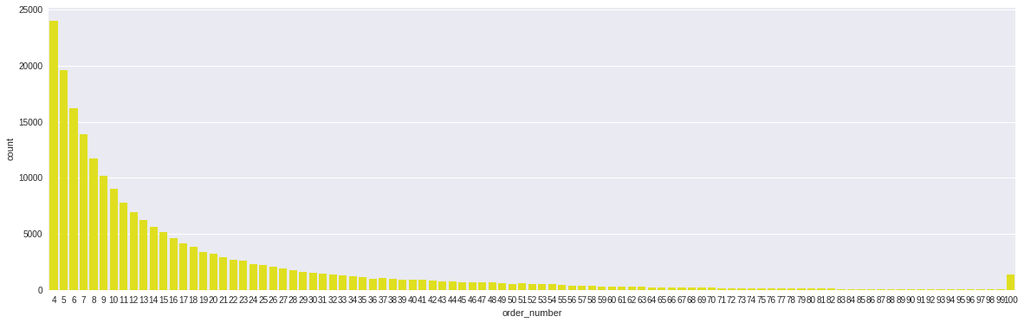

```python
fig, ax = plt.subplots(figsize=(20,6))
sns.countplot(x=orders.groupby("user_id")["order_number"].aggregate(np.max), data=orders, color='yellow')
```

- 각 소비자별 최대 주문 횟수는 4~100회
- 주문 횟수가 급격하게 감소.. 사람들이 주문을 몇십번씩 하거나 그러지는 않는거 같다

#### 가설: 만약 order id의 숫자값이 작을수록 옛날에 구매한 것이다.

만약 가설이 사실이라면, order id간의 차이의 평균을 구해서 다음에는 언제쯤 구매할지 알 수 있다.

but, 가설을 뒷받침할 근거가 없음

## 4-1. 결측치 확인

```python
orders.isnull().any()
```

```
order_id                  False
user_id                   False
eval_set                  False
order_number              False
order_dow                 False
order_hour_of_day         False
days_since_prior_order     True
dtype: bool
```

```python
orders.isnull().sum()
```

```
order_id                       0
user_id                        0
eval_set                       0
order_number                   0
order_dow                      0
order_hour_of_day              0
days_since_prior_order    206209
dtype: int64
```

```python
206209 /3421083 *100
```

```
6.027594185817766
```

결측치가 6%밖에 안되고, 사실상 days since prior order를 알아낼 방법이 없기 때문에 그냥 삭제하고 진행한다...!

```python
orders=orders.dropna()
```

#### 라고 생각했지만.. 뒤에서 다른 데이터들과 merge했을 때 삭제한 row에 해당했던 모든 column이 NaN으로 뜨기 때문에... 결측치 그대로 냅두고 진행한다.......... 그래프 모양은 결측치 삭제 여부에 영향을 눈에 띄게 받지 않아서 다행쓰..

```python
orders=pd.read_csv('orders.csv')
```

## 4-2. day of week 별 주문 건수

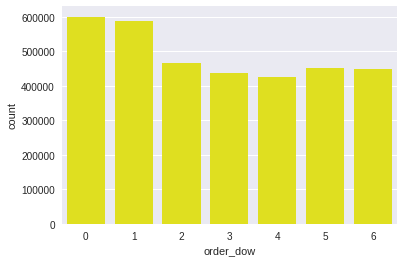

```python
sns.countplot(x="order_dow", data=orders, color='yellow')
```

#### day 0 (sunday)과 day 1(monday, i guess)에 주문이 제일 많다

(삭제했지만, 결측치를 없애기 전후의 그래프 형태 차이가 미미하다)

## 4-3. hour of day 별 주문건수

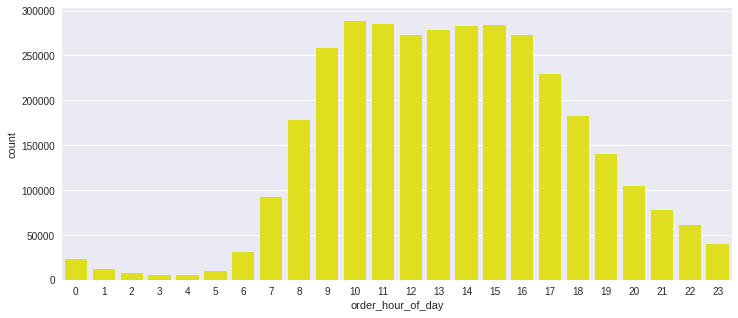

```python
fig, ax = plt.subplots(figsize=(12,5))
sns.countplot(x="order_hour_of_day", data=orders, color='yellow')
```

#### 오전 10시~오후 5시에 주문이 제일 많다

## 4-4. 어떤 요일의, 어떤 시간에 가장 많이 주문할까? dow와 hour of day 결합시켜보기

```python
orders
```

[output not shown]

```python
orders.groupby(["order_dow", "order_hour_of_day"]).aggregate('count').reset_index()
```

|  | order_dow | order_hour_of_day | order_id | user_id | eval_set | order_number | days_since_prior_order |
| --- | --- | --- | --- | --- | --- | --- | --- |
| 0 | 0 | 0 | 3936 | 3936 | 3936 | 3936 | 3690 |
| 1 | 0 | 1 | 2398 | 2398 | 2398 | 2398 | 2245 |
| 2 | 0 | 2 | 1409 | 1409 | 1409 | 1409 | 1296 |
| 3 | 0 | 3 | 963 | 963 | 963 | 963 | 902 |
| 4 | 0 | 4 | 813 | 813 | 813 | 813 | 756 |
| 5 | 0 | 5 | 1168 | 1168 | 1168 | 1168 | 1093 |
| 6 | 0 | 6 | 3329 | 3329 | 3329 | 3329 | 3143 |
| 7 | 0 | 7 | 12410 | 12410 | 12410 | 12410 | 11762 |
| 8 | 0 | 8 | 28108 | 28108 | 28108 | 28108 | 26514 |
| 9 | 0 | 9 | 40798 | 40798 | 40798 | 40798 | 38363 |
| 10 | 0 | 10 | 48465 | 48465 | 48465 | 48465 | 45398 |
| 11 | 0 | 11 | 51035 | 51035 | 51035 | 51035 | 47806 |
| 12 | 0 | 12 | 51443 | 51443 | 51443 | 51443 | 48035 |
| 13 | 0 | 13 | 53849 | 53849 | 53849 | 53849 | 50372 |
| 14 | 0 | 14 | 54552 | 54552 | 54552 | 54552 | 51038 |
| 15 | 0 | 15 | 53954 | 53954 | 53954 | 53954 | 50427 |
| 16 | 0 | 16 | 49463 | 49463 | 49463 | 49463 | 46136 |
| 17 | 0 | 17 | 39753 | 39753 | 39753 | 39753 | 37056 |
| 18 | 0 | 18 | 29572 | 29572 | 29572 | 29572 | 27588 |
| 19 | 0 | 19 | 22654 | 22654 | 22654 | 22654 | 21126 |
| 20 | 0 | 20 | 18277 | 18277 | 18277 | 18277 | 17062 |
| 21 | 0 | 21 | 14423 | 14423 | 14423 | 14423 | 13577 |
| 22 | 0 | 22 | 11246 | 11246 | 11246 | 11246 | 10543 |
| 23 | 0 | 23 | 6887 | 6887 | 6887 | 6887 | 6460 |
| 24 | 1 | 0 | 3674 | 3674 | 3674 | 3674 | 3429 |
| 25 | 1 | 1 | 1830 | 1830 | 1830 | 1830 | 1723 |
| 26 | 1 | 2 | 1105 | 1105 | 1105 | 1105 | 1020 |
| 27 | 1 | 3 | 748 | 748 | 748 | 748 | 696 |
| 28 | 1 | 4 | 809 | 809 | 809 | 809 | 756 |
| 29 | 1 | 5 | 1607 | 1607 | 1607 | 1607 | 1523 |
| ... | ... | ... | ... | ... | ... | ... | ... |
| 138 | 5 | 18 | 24310 | 24310 | 24310 | 24310 | 22806 |
| 139 | 5 | 19 | 18741 | 18741 | 18741 | 18741 | 17517 |
| 140 | 5 | 20 | 13322 | 13322 | 13322 | 13322 | 12500 |
| 141 | 5 | 21 | 9515 | 9515 | 9515 | 9515 | 8945 |
| 142 | 5 | 22 | 7498 | 7498 | 7498 | 7498 | 7013 |
| 143 | 5 | 23 | 5265 | 5265 | 5265 | 5265 | 4926 |
| 144 | 6 | 0 | 3306 | 3306 | 3306 | 3306 | 3080 |
| 145 | 6 | 1 | 1919 | 1919 | 1919 | 1919 | 1815 |
| 146 | 6 | 2 | 1214 | 1214 | 1214 | 1214 | 1130 |
| 147 | 6 | 3 | 863 | 863 | 863 | 863 | 804 |
| 148 | 6 | 4 | 802 | 802 | 802 | 802 | 739 |
| 149 | 6 | 5 | 1136 | 1136 | 1136 | 1136 | 1056 |
| 150 | 6 | 6 | 3243 | 3243 | 3243 | 3243 | 3063 |
| 151 | 6 | 7 | 11319 | 11319 | 11319 | 11319 | 10696 |
| 152 | 6 | 8 | 22960 | 22960 | 22960 | 22960 | 21696 |
| 153 | 6 | 9 | 30839 | 30839 | 30839 | 30839 | 29012 |
| 154 | 6 | 10 | 35665 | 35665 | 35665 | 35665 | 33397 |
| 155 | 6 | 11 | 36994 | 36994 | 36994 | 36994 | 34623 |
| 156 | 6 | 12 | 37121 | 37121 | 37121 | 37121 | 34673 |
| 157 | 6 | 13 | 37564 | 37564 | 37564 | 37564 | 35116 |
| 158 | 6 | 14 | 38748 | 38748 | 38748 | 38748 | 36325 |
| 159 | 6 | 15 | 38093 | 38093 | 38093 | 38093 | 35608 |
| 160 | 6 | 16 | 35562 | 35562 | 35562 | 35562 | 33194 |
| 161 | 6 | 17 | 30398 | 30398 | 30398 | 30398 | 28342 |
| 162 | 6 | 18 | 24157 | 24157 | 24157 | 24157 | 22562 |
| 163 | 6 | 19 | 18346 | 18346 | 18346 | 18346 | 17128 |
| 164 | 6 | 20 | 13392 | 13392 | 13392 | 13392 | 12486 |
| 165 | 6 | 21 | 10501 | 10501 | 10501 | 10501 | 9842 |
| 166 | 6 | 22 | 8532 | 8532 | 8532 | 8532 | 7973 |
| 167 | 6 | 23 | 6087 | 6087 | 6087 | 6087 | 5710 |

168 rows × 7 columns

```python
orders.groupby(["order_dow", "order_hour_of_day"]).size().reset_index()
```

|  | order_dow | order_hour_of_day | 0 |
| --- | --- | --- | --- |
| 0 | 0 | 0 | 3936 |
| 1 | 0 | 1 | 2398 |
| 2 | 0 | 2 | 1409 |
| 3 | 0 | 3 | 963 |
| 4 | 0 | 4 | 813 |
| 5 | 0 | 5 | 1168 |
| 6 | 0 | 6 | 3329 |
| 7 | 0 | 7 | 12410 |
| 8 | 0 | 8 | 28108 |
| 9 | 0 | 9 | 40798 |
| 10 | 0 | 10 | 48465 |
| 11 | 0 | 11 | 51035 |
| 12 | 0 | 12 | 51443 |
| 13 | 0 | 13 | 53849 |
| 14 | 0 | 14 | 54552 |
| 15 | 0 | 15 | 53954 |
| 16 | 0 | 16 | 49463 |
| 17 | 0 | 17 | 39753 |
| 18 | 0 | 18 | 29572 |
| 19 | 0 | 19 | 22654 |
| 20 | 0 | 20 | 18277 |
| 21 | 0 | 21 | 14423 |
| 22 | 0 | 22 | 11246 |
| 23 | 0 | 23 | 6887 |
| 24 | 1 | 0 | 3674 |
| 25 | 1 | 1 | 1830 |
| 26 | 1 | 2 | 1105 |
| 27 | 1 | 3 | 748 |
| 28 | 1 | 4 | 809 |
| 29 | 1 | 5 | 1607 |
| ... | ... | ... | ... |
| 138 | 5 | 18 | 24310 |
| 139 | 5 | 19 | 18741 |
| 140 | 5 | 20 | 13322 |
| 141 | 5 | 21 | 9515 |
| 142 | 5 | 22 | 7498 |
| 143 | 5 | 23 | 5265 |
| 144 | 6 | 0 | 3306 |
| 145 | 6 | 1 | 1919 |
| 146 | 6 | 2 | 1214 |
| 147 | 6 | 3 | 863 |
| 148 | 6 | 4 | 802 |
| 149 | 6 | 5 | 1136 |
| 150 | 6 | 6 | 3243 |
| 151 | 6 | 7 | 11319 |
| 152 | 6 | 8 | 22960 |
| 153 | 6 | 9 | 30839 |
| 154 | 6 | 10 | 35665 |
| 155 | 6 | 11 | 36994 |
| 156 | 6 | 12 | 37121 |
| 157 | 6 | 13 | 37564 |
| 158 | 6 | 14 | 38748 |
| 159 | 6 | 15 | 38093 |
| 160 | 6 | 16 | 35562 |
| 161 | 6 | 17 | 30398 |
| 162 | 6 | 18 | 24157 |
| 163 | 6 | 19 | 18346 |
| 164 | 6 | 20 | 13392 |
| 165 | 6 | 21 | 10501 |
| 166 | 6 | 22 | 8532 |
| 167 | 6 | 23 | 6087 |

168 rows × 3 columns

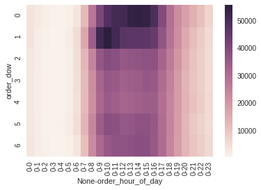

```python
orders_heat = orders.groupby(["order_dow", "order_hour_of_day"]).size().reset_index()
orders_heat = orders_heat.pivot("order_dow", "order_hour_of_day")
sns.heatmap(orders_heat)
```

#### 일요일 10~17시, 월요일 9~11시가 두드러짐

## 4-5. days since prior order 별 주문건수

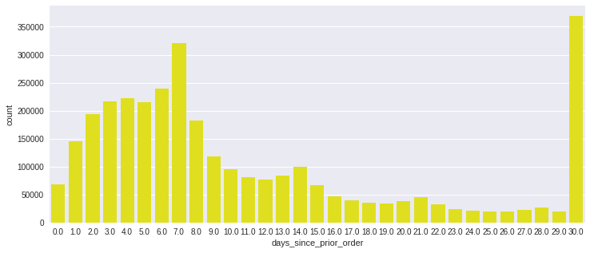

```python
fig, ax = plt.subplots(figsize=(12,5))
sns.countplot(x="days_since_prior_order", data=orders, color='yellow')
```

- 7이 높다 --> 사람들이 일주일 단위로 주문을 많이 하는 것 같다
- 30이 높다 --> 사람들이 한달 단위로 주문을 많이 하는 것 같다
- 두 집단 사이에 교집합이 있는지 알고 싶은데 쉽게 추론하기 힘들다

# 5. orders products train

```python
opt = pd.read_csv('order_products__train.csv')
```

```python
opt
```

|  | order_id | product_id | add_to_cart_order | reordered |
| --- | --- | --- | --- | --- |
| 0 | 1 | 49302 | 1 | 1 |
| 1 | 1 | 11109 | 2 | 1 |
| 2 | 1 | 10246 | 3 | 0 |
| 3 | 1 | 49683 | 4 | 0 |
| 4 | 1 | 43633 | 5 | 1 |
| 5 | 1 | 13176 | 6 | 0 |
| 6 | 1 | 47209 | 7 | 0 |
| 7 | 1 | 22035 | 8 | 1 |
| 8 | 36 | 39612 | 1 | 0 |
| 9 | 36 | 19660 | 2 | 1 |
| 10 | 36 | 49235 | 3 | 0 |
| 11 | 36 | 43086 | 4 | 1 |
| 12 | 36 | 46620 | 5 | 1 |
| 13 | 36 | 34497 | 6 | 1 |
| 14 | 36 | 48679 | 7 | 1 |
| 15 | 36 | 46979 | 8 | 1 |
| 16 | 38 | 11913 | 1 | 0 |
| 17 | 38 | 18159 | 2 | 0 |
| 18 | 38 | 4461 | 3 | 0 |
| 19 | 38 | 21616 | 4 | 1 |
| 20 | 38 | 23622 | 5 | 0 |
| 21 | 38 | 32433 | 6 | 0 |
| 22 | 38 | 28842 | 7 | 0 |
| 23 | 38 | 42625 | 8 | 0 |
| 24 | 38 | 39693 | 9 | 0 |
| 25 | 96 | 20574 | 1 | 1 |
| 26 | 96 | 30391 | 2 | 0 |
| 27 | 96 | 40706 | 3 | 1 |
| 28 | 96 | 25610 | 4 | 0 |
| 29 | 96 | 27966 | 5 | 1 |
| ... | ... | ... | ... | ... |
| 1384587 | 3421026 | 32237 | 3 | 0 |
| 1384588 | 3421026 | 10 | 4 | 0 |
| 1384589 | 3421026 | 4493 | 5 | 0 |
| 1384590 | 3421026 | 7781 | 6 | 0 |
| 1384591 | 3421049 | 40800 | 1 | 0 |
| 1384592 | 3421049 | 17706 | 2 | 0 |
| 1384593 | 3421049 | 33424 | 3 | 1 |
| 1384594 | 3421049 | 17299 | 4 | 0 |
| 1384595 | 3421049 | 26800 | 5 | 0 |
| 1384596 | 3421049 | 34243 | 6 | 0 |
| 1384597 | 3421056 | 5750 | 1 | 1 |
| 1384598 | 3421056 | 9340 | 2 | 1 |
| 1384599 | 3421056 | 21709 | 3 | 1 |
| 1384600 | 3421056 | 16475 | 4 | 0 |
| 1384601 | 3421056 | 12432 | 5 | 0 |
| 1384602 | 3421058 | 15629 | 1 | 1 |
| 1384603 | 3421058 | 4347 | 2 | 1 |
| 1384604 | 3421058 | 34466 | 3 | 1 |
| 1384605 | 3421058 | 6244 | 4 | 1 |
| 1384606 | 3421058 | 6858 | 5 | 1 |
| 1384607 | 3421058 | 30316 | 6 | 1 |
| 1384608 | 3421058 | 35578 | 7 | 0 |
| 1384609 | 3421058 | 32650 | 8 | 1 |
| 1384610 | 3421063 | 49235 | 1 | 1 |
| 1384611 | 3421063 | 13565 | 2 | 1 |
| 1384612 | 3421063 | 14233 | 3 | 1 |
| 1384613 | 3421063 | 35548 | 4 | 1 |
| 1384614 | 3421070 | 35951 | 1 | 1 |
| 1384615 | 3421070 | 16953 | 2 | 1 |
| 1384616 | 3421070 | 4724 | 3 | 1 |

1384617 rows × 4 columns

```python
opt.groupby('product_id').size().sort_values(ascending=False)
```

```
product_id
24852    18726
13176    15480
21137    10894
21903     9784
47626     8135
47766     7409
47209     7293
16797     6494
26209     6033
27966     5546
39275     4966
27845     4908
30391     4613
45007     4589
```

[output cut: 48 more lines]

24852를 merged_prod_ais_dep 에서 lambda를 이용해서 찾았더니 int가 아니라 str값으로 저장되어 있었다 (지워버렸어요....)

## 5-1. opt를 merged_prod_ais_dep, orders와 합치기

opt에는 int로 저장되어 있고 merged 에는 str으로 저장되어 있어서 merge를 계속 시도해도 NaN값이 뜨는 거였다 (이것도 지워버렸어요..) --> 해결: merged의 product_id의 값들을 int로 바꿔주기

```python
merged_prod_ais_dep.product_id = pd.to_numeric(merged_prod_ais_dep.product_id, errors='coerce')
```

```python
opt_final = pd.merge(opt, merged_prod_ais_dep, on='product_id', how='left').drop_duplicates()
opt_final
```

|  | order_id | product_id | add_to_cart_order | reordered | product_name | aisle_id | department_id | aisle | department |
| --- | --- | --- | --- | --- | --- | --- | --- | --- | --- |
| 0 | 1 | 49302 | 1 | 1 | Bulgarian Yogurt | 120 | 16 | yogurt | dairy eggs |
| 3 | 1 | 11109 | 2 | 1 | Organic 4% Milk Fat Whole Milk Cottage Cheese | 108 | 16 | other creams cheeses | dairy eggs |
| 4 | 1 | 10246 | 3 | 0 | Organic Celery Hearts | 83 | 4 | fresh vegetables | produce |
| 5 | 1 | 49683 | 4 | 0 | Cucumber Kirby | 83 | 4 | fresh vegetables | produce |
| 8 | 1 | 43633 | 5 | 1 | Lightly Smoked Sardines in Olive Oil | 95 | 15 | canned meat seafood | canned goods |
| 10 | 1 | 13176 | 6 | 0 | Bag of Organic Bananas | 24 | 4 | fresh fruits | produce |
| 11 | 1 | 47209 | 7 | 0 | Organic Hass Avocado | 24 | 4 | fresh fruits | produce |
| 13 | 1 | 22035 | 8 | 1 | Organic Whole String Cheese | 21 | 16 | packaged cheese | dairy eggs |
| 14 | 36 | 39612 | 1 | 0 | Grated Pecorino Romano Cheese | 2 | 16 | specialty cheeses | dairy eggs |
| 16 | 36 | 19660 | 2 | 1 | Spring Water | 115 | 7 | water seltzer sparkling water | beverages |
| 17 | 36 | 49235 | 3 | 0 | Organic Half & Half | 53 | 16 | cream | dairy eggs |
| 20 | 36 | 43086 | 4 | 1 | Super Greens Salad | 123 | 4 | packaged vegetables fruits | produce |
| 22 | 36 | 46620 | 5 | 1 | Cage Free Extra Large Grade AA Eggs | 86 | 16 | eggs | dairy eggs |
| 24 | 36 | 34497 | 6 | 1 | Prosciutto, Americano | 96 | 20 | lunch meat | deli |
| 26 | 36 | 48679 | 7 | 1 | Organic Garnet Sweet Potato (Yam) | 83 | 4 | fresh vegetables | produce |
| 29 | 36 | 46979 | 8 | 1 | Asparagus | 83 | 4 | fresh vegetables | produce |
| 31 | 38 | 11913 | 1 | 0 | Shelled Pistachios | 117 | 19 | nuts seeds dried fruit | snacks |
| 32 | 38 | 18159 | 2 | 0 | Organic Biologique Limes | 123 | 4 | packaged vegetables fruits | produce |
| 33 | 38 | 4461 | 3 | 0 | Organic Raw Unfiltered Apple Cider Vinegar | 19 | 13 | oils vinegars | pantry |
| 34 | 38 | 21616 | 4 | 1 | Organic Baby Arugula | 123 | 4 | packaged vegetables fruits | produce |
| 35 | 38 | 23622 | 5 | 0 | Organic Hot House Tomato | 83 | 4 | fresh vegetables | produce |
| 36 | 38 | 32433 | 6 | 0 | Green Peas | 116 | 1 | frozen produce | frozen |
| 38 | 38 | 28842 | 7 | 0 | Bunched Cilantro | 16 | 4 | fresh herbs | produce |
| 40 | 38 | 42625 | 8 | 0 | Flat Parsley, Bunch | 16 | 4 | fresh herbs | produce |
| 42 | 38 | 39693 | 9 | 0 | Fresh Dill | 16 | 4 | fresh herbs | produce |
| 44 | 96 | 20574 | 1 | 1 | Roasted Turkey | 96 | 20 | lunch meat | deli |
| 45 | 96 | 30391 | 2 | 0 | Organic Cucumber | 83 | 4 | fresh vegetables | produce |
| 47 | 96 | 40706 | 3 | 1 | Organic Grape Tomatoes | 123 | 4 | packaged vegetables fruits | produce |
| 49 | 96 | 25610 | 4 | 0 | Organic Pomegranate Kernels | 116 | 1 | frozen produce | frozen |
| 51 | 96 | 27966 | 5 | 1 | Organic Raspberries | 123 | 4 | packaged vegetables fruits | produce |
| ... | ... | ... | ... | ... | ... | ... | ... | ... | ... |
| 2167507 | 3421026 | 32237 | 3 | 0 | Campanelle Pasta | 131 | 9 | dry pasta | dry goods pasta |
| 2167509 | 3421026 | 10 | 4 | 0 | Sparkling Orange Juice & Prickly Pear Beverage | 115 | 7 | water seltzer sparkling water | beverages |
| 2167510 | 3421026 | 4493 | 5 | 0 | Italian Sparkling Pomegranate And Orange Soda | 115 | 7 | water seltzer sparkling water | beverages |
| 2167511 | 3421026 | 7781 | 6 | 0 | Organic Sticks Low Moisture Part Skim Mozzarel... | 21 | 16 | packaged cheese | dairy eggs |
| 2167512 | 3421049 | 40800 | 1 | 0 | Gluten Free Rice Bread | 58 | 1 | frozen breads doughs | frozen |
| 2167514 | 3421049 | 17706 | 2 | 0 | Organic Whole Grain Wheat English Muffins | 93 | 3 | breakfast bakery | bakery |
| 2167515 | 3421049 | 33424 | 3 | 1 | Lemon Sports Drink | 64 | 7 | energy sports drinks | beverages |
| 2167517 | 3421049 | 17299 | 4 | 0 | Organic Grated Ginger | 81 | 15 | canned jarred vegetables | canned goods |
| 2167518 | 3421049 | 26800 | 5 | 0 | Organic Baby Kale Mix | 123 | 4 | packaged vegetables fruits | produce |
| 2167520 | 3421049 | 34243 | 6 | 0 | Organic Baby Broccoli | 83 | 4 | fresh vegetables | produce |
| 2167522 | 3421056 | 5750 | 1 | 1 | Total Plain Greek Strained Yogurt | 120 | 16 | yogurt | dairy eggs |
| 2167523 | 3421056 | 9340 | 2 | 1 | Homestyle Classics Meatloaf | 38 | 1 | frozen meals | frozen |
| 2167524 | 3421056 | 21709 | 3 | 1 | Sparkling Lemon Water | 115 | 7 | water seltzer sparkling water | beverages |
| 2167525 | 3421056 | 16475 | 4 | 0 | Brioche Buns | 43 | 3 | buns rolls | bakery |
| 2167526 | 3421056 | 12432 | 5 | 0 | Tartar Sauce | 72 | 13 | condiments | pantry |
| 2167527 | 3421058 | 15629 | 1 | 1 | Wine Infused Salame Cheese and Crackers Small ... | 2 | 16 | specialty cheeses | dairy eggs |
| 2167528 | 3421058 | 4347 | 2 | 1 | Extralean Ground Turkey Breast | 49 | 12 | packaged poultry | meat seafood |
| 2167529 | 3421058 | 34466 | 3 | 1 | Sweet Potatoes | 116 | 1 | frozen produce | frozen |
| 2167531 | 3421058 | 6244 | 4 | 1 | Club Soda Lower Sodium | 77 | 7 | soft drinks | beverages |
| 2167532 | 3421058 | 6858 | 5 | 1 | Classic Britannia Crisps | 78 | 19 | crackers | snacks |
| 2167533 | 3421058 | 30316 | 6 | 1 | Baby Brie | 21 | 16 | packaged cheese | dairy eggs |
| 2167535 | 3421058 | 35578 | 7 | 0 | Genoa Salame with White Cheddar Cheese & Toast... | 7 | 12 | packaged meat | meat seafood |
| 2167537 | 3421058 | 32650 | 8 | 1 | White Giant Paper Towel Rolls | 54 | 17 | paper goods | household |
| 2167539 | 3421063 | 49235 | 1 | 1 | Organic Half & Half | 53 | 16 | cream | dairy eggs |
| 2167542 | 3421063 | 13565 | 2 | 1 | No Salt Added Gluten-Free Blue Chips Made with... | 107 | 19 | chips pretzels | snacks |
| 2167543 | 3421063 | 14233 | 3 | 1 | Natural Artesian Water | 115 | 7 | water seltzer sparkling water | beverages |
| 2167544 | 3421063 | 35548 | 4 | 1 | Twice Baked Potatoes | 13 | 20 | prepared meals | deli |
| 2167546 | 3421070 | 35951 | 1 | 1 | Organic Unsweetened Almond Milk | 91 | 16 | soy lactosefree | dairy eggs |
| 2167548 | 3421070 | 16953 | 2 | 1 | Creamy Peanut Butter | 88 | 13 | spreads | pantry |
| 2167549 | 3421070 | 4724 | 3 | 1 | Broccoli Florettes | 32 | 4 | packaged produce | produce |

1384617 rows × 9 columns

```python
opt_final = pd.merge(opt_final, orders, on='order_id', how='left').drop_duplicates()
opt_final
```

|  | order_id | product_id | add_to_cart_order | reordered | product_name | aisle_id | department_id | aisle | department | user_id | eval_set | order_number | order_dow | order_hour_of_day | days_since_prior_order |
| --- | --- | --- | --- | --- | --- | --- | --- | --- | --- | --- | --- | --- | --- | --- | --- |
| 0 | 1 | 49302 | 1 | 1 | Bulgarian Yogurt | 120 | 16 | yogurt | dairy eggs | 112108 | train | 4 | 4 | 10 | 9.0 |
| 1 | 1 | 11109 | 2 | 1 | Organic 4% Milk Fat Whole Milk Cottage Cheese | 108 | 16 | other creams cheeses | dairy eggs | 112108 | train | 4 | 4 | 10 | 9.0 |
| 2 | 1 | 10246 | 3 | 0 | Organic Celery Hearts | 83 | 4 | fresh vegetables | produce | 112108 | train | 4 | 4 | 10 | 9.0 |
| 3 | 1 | 49683 | 4 | 0 | Cucumber Kirby | 83 | 4 | fresh vegetables | produce | 112108 | train | 4 | 4 | 10 | 9.0 |
| 4 | 1 | 43633 | 5 | 1 | Lightly Smoked Sardines in Olive Oil | 95 | 15 | canned meat seafood | canned goods | 112108 | train | 4 | 4 | 10 | 9.0 |
| 5 | 1 | 13176 | 6 | 0 | Bag of Organic Bananas | 24 | 4 | fresh fruits | produce | 112108 | train | 4 | 4 | 10 | 9.0 |
| 6 | 1 | 47209 | 7 | 0 | Organic Hass Avocado | 24 | 4 | fresh fruits | produce | 112108 | train | 4 | 4 | 10 | 9.0 |
| 7 | 1 | 22035 | 8 | 1 | Organic Whole String Cheese | 21 | 16 | packaged cheese | dairy eggs | 112108 | train | 4 | 4 | 10 | 9.0 |
| 8 | 36 | 39612 | 1 | 0 | Grated Pecorino Romano Cheese | 2 | 16 | specialty cheeses | dairy eggs | 79431 | train | 23 | 6 | 18 | 30.0 |
| 9 | 36 | 19660 | 2 | 1 | Spring Water | 115 | 7 | water seltzer sparkling water | beverages | 79431 | train | 23 | 6 | 18 | 30.0 |
| 10 | 36 | 49235 | 3 | 0 | Organic Half & Half | 53 | 16 | cream | dairy eggs | 79431 | train | 23 | 6 | 18 | 30.0 |
| 11 | 36 | 43086 | 4 | 1 | Super Greens Salad | 123 | 4 | packaged vegetables fruits | produce | 79431 | train | 23 | 6 | 18 | 30.0 |
| 12 | 36 | 46620 | 5 | 1 | Cage Free Extra Large Grade AA Eggs | 86 | 16 | eggs | dairy eggs | 79431 | train | 23 | 6 | 18 | 30.0 |
| 13 | 36 | 34497 | 6 | 1 | Prosciutto, Americano | 96 | 20 | lunch meat | deli | 79431 | train | 23 | 6 | 18 | 30.0 |
| 14 | 36 | 48679 | 7 | 1 | Organic Garnet Sweet Potato (Yam) | 83 | 4 | fresh vegetables | produce | 79431 | train | 23 | 6 | 18 | 30.0 |
| 15 | 36 | 46979 | 8 | 1 | Asparagus | 83 | 4 | fresh vegetables | produce | 79431 | train | 23 | 6 | 18 | 30.0 |
| 16 | 38 | 11913 | 1 | 0 | Shelled Pistachios | 117 | 19 | nuts seeds dried fruit | snacks | 42756 | train | 6 | 6 | 16 | 24.0 |
| 17 | 38 | 18159 | 2 | 0 | Organic Biologique Limes | 123 | 4 | packaged vegetables fruits | produce | 42756 | train | 6 | 6 | 16 | 24.0 |
| 18 | 38 | 4461 | 3 | 0 | Organic Raw Unfiltered Apple Cider Vinegar | 19 | 13 | oils vinegars | pantry | 42756 | train | 6 | 6 | 16 | 24.0 |
| 19 | 38 | 21616 | 4 | 1 | Organic Baby Arugula | 123 | 4 | packaged vegetables fruits | produce | 42756 | train | 6 | 6 | 16 | 24.0 |
| 20 | 38 | 23622 | 5 | 0 | Organic Hot House Tomato | 83 | 4 | fresh vegetables | produce | 42756 | train | 6 | 6 | 16 | 24.0 |
| 21 | 38 | 32433 | 6 | 0 | Green Peas | 116 | 1 | frozen produce | frozen | 42756 | train | 6 | 6 | 16 | 24.0 |
| 22 | 38 | 28842 | 7 | 0 | Bunched Cilantro | 16 | 4 | fresh herbs | produce | 42756 | train | 6 | 6 | 16 | 24.0 |
| 23 | 38 | 42625 | 8 | 0 | Flat Parsley, Bunch | 16 | 4 | fresh herbs | produce | 42756 | train | 6 | 6 | 16 | 24.0 |
| 24 | 38 | 39693 | 9 | 0 | Fresh Dill | 16 | 4 | fresh herbs | produce | 42756 | train | 6 | 6 | 16 | 24.0 |
| 25 | 96 | 20574 | 1 | 1 | Roasted Turkey | 96 | 20 | lunch meat | deli | 17227 | train | 7 | 6 | 20 | 30.0 |
| 26 | 96 | 30391 | 2 | 0 | Organic Cucumber | 83 | 4 | fresh vegetables | produce | 17227 | train | 7 | 6 | 20 | 30.0 |
| 27 | 96 | 40706 | 3 | 1 | Organic Grape Tomatoes | 123 | 4 | packaged vegetables fruits | produce | 17227 | train | 7 | 6 | 20 | 30.0 |
| 28 | 96 | 25610 | 4 | 0 | Organic Pomegranate Kernels | 116 | 1 | frozen produce | frozen | 17227 | train | 7 | 6 | 20 | 30.0 |
| 29 | 96 | 27966 | 5 | 1 | Organic Raspberries | 123 | 4 | packaged vegetables fruits | produce | 17227 | train | 7 | 6 | 20 | 30.0 |
| ... | ... | ... | ... | ... | ... | ... | ... | ... | ... | ... | ... | ... | ... | ... | ... |
| 1384587 | 3421026 | 32237 | 3 | 0 | Campanelle Pasta | 131 | 9 | dry pasta | dry goods pasta | 174668 | train | 4 | 0 | 20 | 30.0 |
| 1384588 | 3421026 | 10 | 4 | 0 | Sparkling Orange Juice & Prickly Pear Beverage | 115 | 7 | water seltzer sparkling water | beverages | 174668 | train | 4 | 0 | 20 | 30.0 |
| 1384589 | 3421026 | 4493 | 5 | 0 | Italian Sparkling Pomegranate And Orange Soda | 115 | 7 | water seltzer sparkling water | beverages | 174668 | train | 4 | 0 | 20 | 30.0 |
| 1384590 | 3421026 | 7781 | 6 | 0 | Organic Sticks Low Moisture Part Skim Mozzarel... | 21 | 16 | packaged cheese | dairy eggs | 174668 | train | 4 | 0 | 20 | 30.0 |
| 1384591 | 3421049 | 40800 | 1 | 0 | Gluten Free Rice Bread | 58 | 1 | frozen breads doughs | frozen | 189544 | train | 4 | 1 | 9 | 3.0 |
| 1384592 | 3421049 | 17706 | 2 | 0 | Organic Whole Grain Wheat English Muffins | 93 | 3 | breakfast bakery | bakery | 189544 | train | 4 | 1 | 9 | 3.0 |
| 1384593 | 3421049 | 33424 | 3 | 1 | Lemon Sports Drink | 64 | 7 | energy sports drinks | beverages | 189544 | train | 4 | 1 | 9 | 3.0 |
| 1384594 | 3421049 | 17299 | 4 | 0 | Organic Grated Ginger | 81 | 15 | canned jarred vegetables | canned goods | 189544 | train | 4 | 1 | 9 | 3.0 |
| 1384595 | 3421049 | 26800 | 5 | 0 | Organic Baby Kale Mix | 123 | 4 | packaged vegetables fruits | produce | 189544 | train | 4 | 1 | 9 | 3.0 |
| 1384596 | 3421049 | 34243 | 6 | 0 | Organic Baby Broccoli | 83 | 4 | fresh vegetables | produce | 189544 | train | 4 | 1 | 9 | 3.0 |
| 1384597 | 3421056 | 5750 | 1 | 1 | Total Plain Greek Strained Yogurt | 120 | 16 | yogurt | dairy eggs | 83898 | train | 13 | 2 | 20 | 11.0 |
| 1384598 | 3421056 | 9340 | 2 | 1 | Homestyle Classics Meatloaf | 38 | 1 | frozen meals | frozen | 83898 | train | 13 | 2 | 20 | 11.0 |
| 1384599 | 3421056 | 21709 | 3 | 1 | Sparkling Lemon Water | 115 | 7 | water seltzer sparkling water | beverages | 83898 | train | 13 | 2 | 20 | 11.0 |
| 1384600 | 3421056 | 16475 | 4 | 0 | Brioche Buns | 43 | 3 | buns rolls | bakery | 83898 | train | 13 | 2 | 20 | 11.0 |
| 1384601 | 3421056 | 12432 | 5 | 0 | Tartar Sauce | 72 | 13 | condiments | pantry | 83898 | train | 13 | 2 | 20 | 11.0 |
| 1384602 | 3421058 | 15629 | 1 | 1 | Wine Infused Salame Cheese and Crackers Small ... | 2 | 16 | specialty cheeses | dairy eggs | 136952 | train | 20 | 3 | 18 | 15.0 |
| 1384603 | 3421058 | 4347 | 2 | 1 | Extralean Ground Turkey Breast | 49 | 12 | packaged poultry | meat seafood | 136952 | train | 20 | 3 | 18 | 15.0 |
| 1384604 | 3421058 | 34466 | 3 | 1 | Sweet Potatoes | 116 | 1 | frozen produce | frozen | 136952 | train | 20 | 3 | 18 | 15.0 |
| 1384605 | 3421058 | 6244 | 4 | 1 | Club Soda Lower Sodium | 77 | 7 | soft drinks | beverages | 136952 | train | 20 | 3 | 18 | 15.0 |
| 1384606 | 3421058 | 6858 | 5 | 1 | Classic Britannia Crisps | 78 | 19 | crackers | snacks | 136952 | train | 20 | 3 | 18 | 15.0 |
| 1384607 | 3421058 | 30316 | 6 | 1 | Baby Brie | 21 | 16 | packaged cheese | dairy eggs | 136952 | train | 20 | 3 | 18 | 15.0 |
| 1384608 | 3421058 | 35578 | 7 | 0 | Genoa Salame with White Cheddar Cheese & Toast... | 7 | 12 | packaged meat | meat seafood | 136952 | train | 20 | 3 | 18 | 15.0 |
| 1384609 | 3421058 | 32650 | 8 | 1 | White Giant Paper Towel Rolls | 54 | 17 | paper goods | household | 136952 | train | 20 | 3 | 18 | 15.0 |
| 1384610 | 3421063 | 49235 | 1 | 1 | Organic Half & Half | 53 | 16 | cream | dairy eggs | 169679 | train | 30 | 0 | 10 | 4.0 |
| 1384611 | 3421063 | 13565 | 2 | 1 | No Salt Added Gluten-Free Blue Chips Made with... | 107 | 19 | chips pretzels | snacks | 169679 | train | 30 | 0 | 10 | 4.0 |
| 1384612 | 3421063 | 14233 | 3 | 1 | Natural Artesian Water | 115 | 7 | water seltzer sparkling water | beverages | 169679 | train | 30 | 0 | 10 | 4.0 |
| 1384613 | 3421063 | 35548 | 4 | 1 | Twice Baked Potatoes | 13 | 20 | prepared meals | deli | 169679 | train | 30 | 0 | 10 | 4.0 |
| 1384614 | 3421070 | 35951 | 1 | 1 | Organic Unsweetened Almond Milk | 91 | 16 | soy lactosefree | dairy eggs | 139822 | train | 15 | 6 | 10 | 8.0 |
| 1384615 | 3421070 | 16953 | 2 | 1 | Creamy Peanut Butter | 88 | 13 | spreads | pantry | 139822 | train | 15 | 6 | 10 | 8.0 |
| 1384616 | 3421070 | 4724 | 3 | 1 | Broccoli Florettes | 32 | 4 | packaged produce | produce | 139822 | train | 15 | 6 | 10 | 8.0 |

1384617 rows × 15 columns

merge를 해보니 duplicate row들이 생겨서 삭제해줬다

```python
opt_final.groupby('product_name').size().sort_values(ascending=False)
```

```
product_name
Banana                                                                                18726
Bag of Organic Bananas                                                                15480
Organic Strawberries                                                                  10894
Organic Baby Spinach                                                                   9784
Large Lemon                                                                            8135
Organic Avocado                                                                        7409
Organic Hass Avocado                                                                   7293
Strawberries                                                                           6494
Limes                                                                                  6033
Organic Raspberries                                                                    5546
Organic Blueberries                                                                    4966
Organic Whole Milk                                                                     4908
Organic Cucumber                                                                       4613
Organic Zucchini                                                                       4589
Organic Yellow Onion                                                                   4290
Organic Garlic                                                                         4158
Seedless Red Grapes                                                                    4059
Asparagus                                                                              3868
Organic Grape Tomatoes                                                                 3823
Organic Red Onion                                                                      3818
Yellow Onions                                                                          3762
Organic Baby Carrots                                                                   3597
Honeycrisp Apple                                                                       3551
Organic Cilantro                                                                       3526
Organic Lemon                                                                          3505
Sparkling Water Grapefruit                                                             3359
Raspberries                                                                            3279
Organic Fuji Apple                                                                     3257
Small Hass Avocado                                                                     3103
Broccoli Crown                                                                         2932
                                                                                      ...
Liquid Laundry Detergent, Island Fresh, 32 Loads 50 Fl Oz Laundry                         1
Ocean Lift Anti-Dandruff Shampoo                                                          1
Original Flavors Jelly Beans                                                              1
Liquid Laundry Detergent, Island Fresh, 64 Loads 100 Fl Oz Laundry                        1
Graduates Lil' Entrees Creamy Chicken Stew with Green Beans & Carrots                     1
Signature Spicy Chicken                                                                   1
Ocean Mist Pods                                                                           1
Ocean Paradise All Purpose Cleaner                                                        1
```

[output cut: 8 more lines]

```
Signature Steakhouse Marinade                                                             1
Silhouette for Women L/XL Briefs                                                          1
Chicken Corn Taquitos                                                                     1
Chicken Crab & Herring Cat Food                                                           1
Enriched Unsweetened Quinoamilk Beverage                                                  1
Original Energy Drink                                                                     1
Silicone Baking Mat                                                                       1
Turkey and Seafood Cat Food                                                               1
Original Effervescent Tablets Antacid                                                     1
Chicken Drummettes                                                                        1
Vienna Turkey Pastrami                                                                    1
Original Dry Rub                                                                          1
Chicken Egg Roll                                                                          1
Kids Apple Detangler Spray                                                                1
dtype: int64
```

#### 결측치 확인

```python
opt_final.isnull().any()
```

```
order_id                  False
product_id                False
add_to_cart_order         False
reordered                 False
product_name              False
aisle_id                  False
department_id             False
aisle                     False
department                False
user_id                   False
eval_set                  False
order_number              False
order_dow                 False
order_hour_of_day         False
days_since_prior_order    False
dtype: bool
```

### days since prior order가 NaN값인 것들은 모두 opp에 있나보다!

train set에 없어서 다행인듯...? (다행이 아닌가..?)

## 5-2. 어떤 aisle의 제품을 좋아할까?

```python
opt_final.groupby('aisle').size().sort_values(ascending=False)
```

```
aisle
fresh vegetables                 150609
fresh fruits                     150473
packaged vegetables fruits        78493
yogurt                            55240
packaged cheese                   41699
water seltzer sparkling water     36617
milk                              32644
chips pretzels                    31269
soy lactosefree                   26240
bread                             23635
refrigerated                      23228
ice cream ice                     22676
frozen produce                    22453
eggs                              19875
crackers                          19592
frozen meals                      18221
energy granola bars               17449
lunch meat                        16957
soft drinks                       16279
cereal                            16201
fresh herbs                       16052
fresh dips tapenades              15142
soup broth bouillon               15109
juice nectars                     14350
packaged produce                  13460
baby food formula                 13198
baking ingredients                13088
other creams cheeses              12820
hot dogs bacon sausage            12813
paper goods                       12694
                                  ...
diapers wipes                      1109
baking supplies decor              1094
white wines                        1088
seafood counter                    1084
air fresheners candles             1067
cocoa drink mixes                  1062
feminine care                      1048
spirits                             967
```

[output cut: 8 more lines]

```
indian foods                        719
bulk grains rice dried goods        634
kosher foods                        628
eye ear care                        548
first aid                           539
skin care                           534
shave needs                         532
ice cream toppings                  504
specialty wines champagnes          461
kitchen supplies                    448
baby bath body care                 328
baby accessories                    306
frozen juice                        294
beauty                              287
dtype: int64
```

바로 위 데이터 가지고 bar graph 그렸는데 커프링스여서 그래프 지웠어요.. 로딩이 넘 늦어져서.. (파일 다 날아가는 줄 알고 식겁했어요..ㅎ)

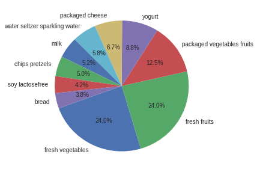

```python
plt.figure(figsize=(5,5))
temp2 = opt_final['aisle'].value_counts().head(10)
labels = (np.array(temp2.index))
sizes = (np.array((temp2 / temp2.sum())*100))
plt.pie(sizes, labels=labels,
        autopct='%1.1f%%', startangle=200)
plt.show()
```

상대적인 비율을 보기엔 pie chart가 낫다

## 5-3. 어떤 department의 제품을 좋아할까?

```python
opt_final.groupby('department').size().sort_values(ascending=False)
```

```
department
produce            409087
dairy eggs         217051
snacks             118862
beverages          114046
frozen             100426
pantry              81242
bakery              48394
canned goods        46799
deli                44291
dry goods pasta     38713
household           35986
meat seafood        30307
breakfast           29500
personal care       21570
babies              14941
international       11902
missing              8251
alcohol              5598
pets                 4497
other                1795
bulk                 1359
dtype: int64
```

[figure not shown]

```python
plt.figure(figsize=(5,5))
temp3 = opt_final['department'].value_counts().head(10)
labels = (np.array(temp2.index))
sizes = (np.array((temp2 / temp2.sum())*100))
plt.pie(sizes, labels=labels,
        autopct='%1.1f%%', startangle=200)
plt.show()
```

# 6. order products prior

캐글 측에서 제공한 정보: order_products__prior.csv contains previous order contents for all customers. 'reordered' indicates that the customer has a previous order that contains the product. Note that some orders will have no reordered items. You may predict an explicit 'None' value for orders with no reordered items. See the evaluation page for full details.

```python
opp = pd.read_csv('order_products__prior.csv')
```

```python
opp
```

|  | order_id | product_id | add_to_cart_order | reordered |
| --- | --- | --- | --- | --- |
| 0 | 2 | 33120 | 1 | 1 |
| 1 | 2 | 28985 | 2 | 1 |
| 2 | 2 | 9327 | 3 | 0 |
| 3 | 2 | 45918 | 4 | 1 |
| 4 | 2 | 30035 | 5 | 0 |
| 5 | 2 | 17794 | 6 | 1 |
| 6 | 2 | 40141 | 7 | 1 |
| 7 | 2 | 1819 | 8 | 1 |
| 8 | 2 | 43668 | 9 | 0 |
| 9 | 3 | 33754 | 1 | 1 |
| 10 | 3 | 24838 | 2 | 1 |
| 11 | 3 | 17704 | 3 | 1 |
| 12 | 3 | 21903 | 4 | 1 |
| 13 | 3 | 17668 | 5 | 1 |
| 14 | 3 | 46667 | 6 | 1 |
| 15 | 3 | 17461 | 7 | 1 |
| 16 | 3 | 32665 | 8 | 1 |
| 17 | 4 | 46842 | 1 | 0 |
| 18 | 4 | 26434 | 2 | 1 |
| 19 | 4 | 39758 | 3 | 1 |
| 20 | 4 | 27761 | 4 | 1 |
| 21 | 4 | 10054 | 5 | 1 |
| 22 | 4 | 21351 | 6 | 1 |
| 23 | 4 | 22598 | 7 | 1 |
| 24 | 4 | 34862 | 8 | 1 |
| 25 | 4 | 40285 | 9 | 1 |
| 26 | 4 | 17616 | 10 | 1 |
| 27 | 4 | 25146 | 11 | 1 |
| 28 | 4 | 32645 | 12 | 1 |
| 29 | 4 | 41276 | 13 | 1 |
| ... | ... | ... | ... | ... |
| 32434459 | 3421080 | 41950 | 4 | 0 |
| 32434460 | 3421080 | 31717 | 5 | 0 |
| 32434461 | 3421080 | 12935 | 6 | 1 |
| 32434462 | 3421080 | 25122 | 7 | 0 |
| 32434463 | 3421080 | 10667 | 8 | 0 |
| 32434464 | 3421080 | 38061 | 9 | 0 |
| 32434465 | 3421081 | 38185 | 1 | 0 |
| 32434466 | 3421081 | 12218 | 2 | 0 |
| 32434467 | 3421081 | 32299 | 3 | 0 |
| 32434468 | 3421081 | 3060 | 4 | 0 |
| 32434469 | 3421081 | 20539 | 5 | 0 |
| 32434470 | 3421081 | 35221 | 6 | 0 |
| 32434471 | 3421081 | 12861 | 7 | 0 |
| 32434472 | 3421082 | 17279 | 1 | 1 |
| 32434473 | 3421082 | 12738 | 2 | 1 |
| 32434474 | 3421082 | 16797 | 3 | 0 |
| 32434475 | 3421082 | 43352 | 4 | 1 |
| 32434476 | 3421082 | 32700 | 5 | 1 |
| 32434477 | 3421082 | 12023 | 6 | 0 |
| 32434478 | 3421082 | 47941 | 7 | 0 |
| 32434479 | 3421083 | 7854 | 1 | 0 |
| 32434480 | 3421083 | 45309 | 2 | 0 |
| 32434481 | 3421083 | 21162 | 3 | 0 |
| 32434482 | 3421083 | 18176 | 4 | 1 |
| 32434483 | 3421083 | 35211 | 5 | 0 |
| 32434484 | 3421083 | 39678 | 6 | 1 |
| 32434485 | 3421083 | 11352 | 7 | 0 |
| 32434486 | 3421083 | 4600 | 8 | 0 |
| 32434487 | 3421083 | 24852 | 9 | 1 |
| 32434488 | 3421083 | 5020 | 10 | 1 |

32434489 rows × 4 columns

## 6-1. opp와 merged, orders 합치기

```python
opp_final=pd.merge(opp, merged_prod_ais_dep, on='product_id', how='left').drop_duplicates()
opp_final
```

|  | order_id | product_id | add_to_cart_order | reordered | product_name | aisle_id | department_id | aisle | department |
| --- | --- | --- | --- | --- | --- | --- | --- | --- | --- |
| 0 | 2 | 33120 | 1 | 1 | Organic Egg Whites | 86 | 16 | eggs | dairy eggs |
| 2 | 2 | 28985 | 2 | 1 | Michigan Organic Kale | 83 | 4 | fresh vegetables | produce |
| 4 | 2 | 9327 | 3 | 0 | Garlic Powder | 104 | 13 | spices seasonings | pantry |
| 5 | 2 | 45918 | 4 | 1 | Coconut Butter | 19 | 13 | oils vinegars | pantry |
| 7 | 2 | 30035 | 5 | 0 | Natural Sweetener | 17 | 13 | baking ingredients | pantry |
| 9 | 2 | 17794 | 6 | 1 | Carrots | 83 | 4 | fresh vegetables | produce |
| 10 | 2 | 40141 | 7 | 1 | Original Unflavored Gelatine Mix | 105 | 13 | doughs gelatins bake mixes | pantry |
| 12 | 2 | 1819 | 8 | 1 | All Natural No Stir Creamy Almond Butter | 88 | 13 | spreads | pantry |
| 13 | 2 | 43668 | 9 | 0 | Classic Blend Cole Slaw | 123 | 4 | packaged vegetables fruits | produce |
| 15 | 3 | 33754 | 1 | 1 | Total 2% with Strawberry Lowfat Greek Strained... | 120 | 16 | yogurt | dairy eggs |
| 17 | 3 | 24838 | 2 | 1 | Unsweetened Almondmilk | 91 | 16 | soy lactosefree | dairy eggs |
| 19 | 3 | 17704 | 3 | 1 | Lemons | 123 | 4 | packaged vegetables fruits | produce |
| 20 | 3 | 21903 | 4 | 1 | Organic Baby Spinach | 123 | 4 | packaged vegetables fruits | produce |
| 21 | 3 | 17668 | 5 | 1 | Unsweetened Chocolate Almond Breeze Almond Milk | 91 | 16 | soy lactosefree | dairy eggs |
| 22 | 3 | 46667 | 6 | 1 | Organic Ginger Root | 83 | 4 | fresh vegetables | produce |
| 24 | 3 | 17461 | 7 | 1 | Air Chilled Organic Boneless Skinless Chicken ... | 35 | 12 | poultry counter | meat seafood |
| 25 | 3 | 32665 | 8 | 1 | Organic Ezekiel 49 Bread Cinnamon Raisin | 112 | 3 | bread | bakery |
| 27 | 4 | 46842 | 1 | 0 | Plain Pre-Sliced Bagels | 93 | 3 | breakfast bakery | bakery |
| 29 | 4 | 26434 | 2 | 1 | Honey/Lemon Cough Drops | 11 | 11 | cold flu allergy | personal care |
| 31 | 4 | 39758 | 3 | 1 | Chewy 25% Low Sugar Chocolate Chip Granola | 3 | 19 | energy granola bars | snacks |
| 33 | 4 | 27761 | 4 | 1 | Oats & Chocolate Chewy Bars | 48 | 14 | breakfast bars pastries | breakfast |
| 35 | 4 | 10054 | 5 | 1 | Kellogg's Nutri-Grain Apple Cinnamon Cereal | 48 | 14 | breakfast bars pastries | breakfast |
| 36 | 4 | 21351 | 6 | 1 | Nutri-Grain Soft Baked Strawberry Cereal Break... | 48 | 14 | breakfast bars pastries | breakfast |
| 37 | 4 | 22598 | 7 | 1 | Kellogg's Nutri-Grain Blueberry Cereal | 48 | 14 | breakfast bars pastries | breakfast |
| 38 | 4 | 34862 | 8 | 1 | Tiny Twists Pretzels | 107 | 19 | chips pretzels | snacks |
| 40 | 4 | 40285 | 9 | 1 | Traditional Snack Mix | 125 | 19 | trail mix snack mix | snacks |
| 42 | 4 | 17616 | 10 | 1 | Goldfish Cheddar Baked Snack Crackers | 78 | 19 | crackers | snacks |
| 43 | 4 | 25146 | 11 | 1 | Original Orange Juice | 31 | 7 | refrigerated | beverages |
| 45 | 4 | 32645 | 12 | 1 | Sugarfree Energy Drink | 64 | 7 | energy sports drinks | beverages |
| 47 | 4 | 41276 | 13 | 1 | Energy Drink | 64 | 7 | energy sports drinks | beverages |
| ... | ... | ... | ... | ... | ... | ... | ... | ... | ... |
| 50819259 | 3421080 | 41950 | 4 | 0 | Organic Tomato Cluster | 83 | 4 | fresh vegetables | produce |
| 50819261 | 3421080 | 31717 | 5 | 0 | Organic Cilantro | 16 | 4 | fresh herbs | produce |
| 50819263 | 3421080 | 12935 | 6 | 1 | Organic Pasture Raised Brown Eggs | 86 | 16 | eggs | dairy eggs |
| 50819264 | 3421080 | 25122 | 7 | 0 | Organic European Style Lightly Salted Butter | 36 | 16 | butter | dairy eggs |
| 50819266 | 3421080 | 10667 | 8 | 0 | Imported Butter | 36 | 16 | butter | dairy eggs |
| 50819267 | 3421080 | 38061 | 9 | 0 | Organic Raw Coconut Butter | 36 | 16 | butter | dairy eggs |
| 50819269 | 3421081 | 38185 | 1 | 0 | Hint of Lime Flavored Tortilla Chips | 107 | 19 | chips pretzels | snacks |
| 50819271 | 3421081 | 12218 | 2 | 0 | Classic Wheat Bread | 112 | 3 | bread | bakery |
| 50819272 | 3421081 | 32299 | 3 | 0 | Dijon Mustard | 72 | 13 | condiments | pantry |
| 50819274 | 3421081 | 3060 | 4 | 0 | Pepper Jack Cheese Slices | 21 | 16 | packaged cheese | dairy eggs |
| 50819275 | 3421081 | 20539 | 5 | 0 | Healthy Kids Chicken Alphabet Condensed Soup | 69 | 15 | soup broth bouillon | canned goods |
| 50819276 | 3421081 | 35221 | 6 | 0 | Lime Sparkling Water | 115 | 7 | water seltzer sparkling water | beverages |
| 50819278 | 3421081 | 12861 | 7 | 0 | Farmer’s Market Vine Ripened Tomato & Basil Hu... | 67 | 20 | fresh dips tapenades | deli |
| 50819279 | 3421082 | 17279 | 1 | 1 | Fresh 99% Lean Ground Turkey | 49 | 12 | packaged poultry | meat seafood |
| 50819280 | 3421082 | 12738 | 2 | 1 | Original Spray | 36 | 16 | butter | dairy eggs |
| 50819281 | 3421082 | 16797 | 3 | 0 | Strawberries | 24 | 4 | fresh fruits | produce |
| 50819282 | 3421082 | 43352 | 4 | 1 | Raspberries | 32 | 4 | packaged produce | produce |
| 50819284 | 3421082 | 32700 | 5 | 1 | Original Whipped Cream | 53 | 16 | cream | dairy eggs |
| 50819286 | 3421082 | 12023 | 6 | 0 | Toasted Coconut Chips Original Recipe | 117 | 19 | nuts seeds dried fruit | snacks |
| 50819287 | 3421082 | 47941 | 7 | 0 | Special K Red Berries Cereal | 121 | 14 | cereal | breakfast |
| 50819289 | 3421083 | 7854 | 1 | 0 | Freeze Dried Mango Slices | 117 | 19 | nuts seeds dried fruit | snacks |
| 50819290 | 3421083 | 45309 | 2 | 0 | Purple Carrot & blueberry Puffs | 92 | 18 | baby food formula | babies |
| 50819292 | 3421083 | 21162 | 3 | 0 | Organic Mixed Berry Yogurt & Fruit Snack | 92 | 18 | baby food formula | babies |
| 50819293 | 3421083 | 18176 | 4 | 1 | Organic Strawberry Yogurt & Fruit Snack | 92 | 18 | baby food formula | babies |
| 50819294 | 3421083 | 35211 | 5 | 0 | Organic Strawberry & Mango Dried Tiny Fruits | 92 | 18 | baby food formula | babies |
| 50819296 | 3421083 | 39678 | 6 | 1 | Free & Clear Natural Dishwasher Detergent | 74 | 17 | dish detergents | household |
| 50819298 | 3421083 | 11352 | 7 | 0 | Organic Mini Sandwich Crackers Peanut Butter | 78 | 19 | crackers | snacks |
| 50819299 | 3421083 | 4600 | 8 | 0 | All Natural French Toast Sticks | 52 | 1 | frozen breakfast | frozen |
| 50819300 | 3421083 | 24852 | 9 | 1 | Banana | 24 | 4 | fresh fruits | produce |
| 50819302 | 3421083 | 5020 | 10 | 1 | Organic Sweet & Salty Peanut Pretzel Granola ... | 3 | 19 | energy granola bars | snacks |

32434489 rows × 9 columns

```python
opp_final = pd.merge(opp_final, orders, on='order_id', how='left').drop_duplicates()
opp_final
```

|  | order_id | product_id | add_to_cart_order | reordered | product_name | aisle_id | department_id | aisle | department | user_id | eval_set | order_number | order_dow | order_hour_of_day | days_since_prior_order |
| --- | --- | --- | --- | --- | --- | --- | --- | --- | --- | --- | --- | --- | --- | --- | --- |
| 0 | 2 | 33120 | 1 | 1 | Organic Egg Whites | 86 | 16 | eggs | dairy eggs | 202279 | prior | 3 | 5 | 9 | 8.0 |
| 1 | 2 | 28985 | 2 | 1 | Michigan Organic Kale | 83 | 4 | fresh vegetables | produce | 202279 | prior | 3 | 5 | 9 | 8.0 |
| 2 | 2 | 9327 | 3 | 0 | Garlic Powder | 104 | 13 | spices seasonings | pantry | 202279 | prior | 3 | 5 | 9 | 8.0 |
| 3 | 2 | 45918 | 4 | 1 | Coconut Butter | 19 | 13 | oils vinegars | pantry | 202279 | prior | 3 | 5 | 9 | 8.0 |
| 4 | 2 | 30035 | 5 | 0 | Natural Sweetener | 17 | 13 | baking ingredients | pantry | 202279 | prior | 3 | 5 | 9 | 8.0 |
| 5 | 2 | 17794 | 6 | 1 | Carrots | 83 | 4 | fresh vegetables | produce | 202279 | prior | 3 | 5 | 9 | 8.0 |
| 6 | 2 | 40141 | 7 | 1 | Original Unflavored Gelatine Mix | 105 | 13 | doughs gelatins bake mixes | pantry | 202279 | prior | 3 | 5 | 9 | 8.0 |
| 7 | 2 | 1819 | 8 | 1 | All Natural No Stir Creamy Almond Butter | 88 | 13 | spreads | pantry | 202279 | prior | 3 | 5 | 9 | 8.0 |
| 8 | 2 | 43668 | 9 | 0 | Classic Blend Cole Slaw | 123 | 4 | packaged vegetables fruits | produce | 202279 | prior | 3 | 5 | 9 | 8.0 |
| 9 | 3 | 33754 | 1 | 1 | Total 2% with Strawberry Lowfat Greek Strained... | 120 | 16 | yogurt | dairy eggs | 205970 | prior | 16 | 5 | 17 | 12.0 |
| 10 | 3 | 24838 | 2 | 1 | Unsweetened Almondmilk | 91 | 16 | soy lactosefree | dairy eggs | 205970 | prior | 16 | 5 | 17 | 12.0 |
| 11 | 3 | 17704 | 3 | 1 | Lemons | 123 | 4 | packaged vegetables fruits | produce | 205970 | prior | 16 | 5 | 17 | 12.0 |
| 12 | 3 | 21903 | 4 | 1 | Organic Baby Spinach | 123 | 4 | packaged vegetables fruits | produce | 205970 | prior | 16 | 5 | 17 | 12.0 |
| 13 | 3 | 17668 | 5 | 1 | Unsweetened Chocolate Almond Breeze Almond Milk | 91 | 16 | soy lactosefree | dairy eggs | 205970 | prior | 16 | 5 | 17 | 12.0 |
| 14 | 3 | 46667 | 6 | 1 | Organic Ginger Root | 83 | 4 | fresh vegetables | produce | 205970 | prior | 16 | 5 | 17 | 12.0 |
| 15 | 3 | 17461 | 7 | 1 | Air Chilled Organic Boneless Skinless Chicken ... | 35 | 12 | poultry counter | meat seafood | 205970 | prior | 16 | 5 | 17 | 12.0 |
| 16 | 3 | 32665 | 8 | 1 | Organic Ezekiel 49 Bread Cinnamon Raisin | 112 | 3 | bread | bakery | 205970 | prior | 16 | 5 | 17 | 12.0 |
| 17 | 4 | 46842 | 1 | 0 | Plain Pre-Sliced Bagels | 93 | 3 | breakfast bakery | bakery | 178520 | prior | 36 | 1 | 9 | 7.0 |
| 18 | 4 | 26434 | 2 | 1 | Honey/Lemon Cough Drops | 11 | 11 | cold flu allergy | personal care | 178520 | prior | 36 | 1 | 9 | 7.0 |
| 19 | 4 | 39758 | 3 | 1 | Chewy 25% Low Sugar Chocolate Chip Granola | 3 | 19 | energy granola bars | snacks | 178520 | prior | 36 | 1 | 9 | 7.0 |
| 20 | 4 | 27761 | 4 | 1 | Oats & Chocolate Chewy Bars | 48 | 14 | breakfast bars pastries | breakfast | 178520 | prior | 36 | 1 | 9 | 7.0 |
| 21 | 4 | 10054 | 5 | 1 | Kellogg's Nutri-Grain Apple Cinnamon Cereal | 48 | 14 | breakfast bars pastries | breakfast | 178520 | prior | 36 | 1 | 9 | 7.0 |
| 22 | 4 | 21351 | 6 | 1 | Nutri-Grain Soft Baked Strawberry Cereal Break... | 48 | 14 | breakfast bars pastries | breakfast | 178520 | prior | 36 | 1 | 9 | 7.0 |
| 23 | 4 | 22598 | 7 | 1 | Kellogg's Nutri-Grain Blueberry Cereal | 48 | 14 | breakfast bars pastries | breakfast | 178520 | prior | 36 | 1 | 9 | 7.0 |
| 24 | 4 | 34862 | 8 | 1 | Tiny Twists Pretzels | 107 | 19 | chips pretzels | snacks | 178520 | prior | 36 | 1 | 9 | 7.0 |
| 25 | 4 | 40285 | 9 | 1 | Traditional Snack Mix | 125 | 19 | trail mix snack mix | snacks | 178520 | prior | 36 | 1 | 9 | 7.0 |
| 26 | 4 | 17616 | 10 | 1 | Goldfish Cheddar Baked Snack Crackers | 78 | 19 | crackers | snacks | 178520 | prior | 36 | 1 | 9 | 7.0 |
| 27 | 4 | 25146 | 11 | 1 | Original Orange Juice | 31 | 7 | refrigerated | beverages | 178520 | prior | 36 | 1 | 9 | 7.0 |
| 28 | 4 | 32645 | 12 | 1 | Sugarfree Energy Drink | 64 | 7 | energy sports drinks | beverages | 178520 | prior | 36 | 1 | 9 | 7.0 |
| 29 | 4 | 41276 | 13 | 1 | Energy Drink | 64 | 7 | energy sports drinks | beverages | 178520 | prior | 36 | 1 | 9 | 7.0 |
| ... | ... | ... | ... | ... | ... | ... | ... | ... | ... | ... | ... | ... | ... | ... | ... |
| 32434459 | 3421080 | 41950 | 4 | 0 | Organic Tomato Cluster | 83 | 4 | fresh vegetables | produce | 52726 | prior | 2 | 1 | 11 | 2.0 |
| 32434460 | 3421080 | 31717 | 5 | 0 | Organic Cilantro | 16 | 4 | fresh herbs | produce | 52726 | prior | 2 | 1 | 11 | 2.0 |
| 32434461 | 3421080 | 12935 | 6 | 1 | Organic Pasture Raised Brown Eggs | 86 | 16 | eggs | dairy eggs | 52726 | prior | 2 | 1 | 11 | 2.0 |
| 32434462 | 3421080 | 25122 | 7 | 0 | Organic European Style Lightly Salted Butter | 36 | 16 | butter | dairy eggs | 52726 | prior | 2 | 1 | 11 | 2.0 |
| 32434463 | 3421080 | 10667 | 8 | 0 | Imported Butter | 36 | 16 | butter | dairy eggs | 52726 | prior | 2 | 1 | 11 | 2.0 |
| 32434464 | 3421080 | 38061 | 9 | 0 | Organic Raw Coconut Butter | 36 | 16 | butter | dairy eggs | 52726 | prior | 2 | 1 | 11 | 2.0 |
| 32434465 | 3421081 | 38185 | 1 | 0 | Hint of Lime Flavored Tortilla Chips | 107 | 19 | chips pretzels | snacks | 117076 | prior | 1 | 3 | 11 | NaN |
| 32434466 | 3421081 | 12218 | 2 | 0 | Classic Wheat Bread | 112 | 3 | bread | bakery | 117076 | prior | 1 | 3 | 11 | NaN |
| 32434467 | 3421081 | 32299 | 3 | 0 | Dijon Mustard | 72 | 13 | condiments | pantry | 117076 | prior | 1 | 3 | 11 | NaN |
| 32434468 | 3421081 | 3060 | 4 | 0 | Pepper Jack Cheese Slices | 21 | 16 | packaged cheese | dairy eggs | 117076 | prior | 1 | 3 | 11 | NaN |
| 32434469 | 3421081 | 20539 | 5 | 0 | Healthy Kids Chicken Alphabet Condensed Soup | 69 | 15 | soup broth bouillon | canned goods | 117076 | prior | 1 | 3 | 11 | NaN |
| 32434470 | 3421081 | 35221 | 6 | 0 | Lime Sparkling Water | 115 | 7 | water seltzer sparkling water | beverages | 117076 | prior | 1 | 3 | 11 | NaN |
| 32434471 | 3421081 | 12861 | 7 | 0 | Farmer’s Market Vine Ripened Tomato & Basil Hu... | 67 | 20 | fresh dips tapenades | deli | 117076 | prior | 1 | 3 | 11 | NaN |
| 32434472 | 3421082 | 17279 | 1 | 1 | Fresh 99% Lean Ground Turkey | 49 | 12 | packaged poultry | meat seafood | 175185 | prior | 23 | 2 | 18 | 4.0 |
| 32434473 | 3421082 | 12738 | 2 | 1 | Original Spray | 36 | 16 | butter | dairy eggs | 175185 | prior | 23 | 2 | 18 | 4.0 |
| 32434474 | 3421082 | 16797 | 3 | 0 | Strawberries | 24 | 4 | fresh fruits | produce | 175185 | prior | 23 | 2 | 18 | 4.0 |
| 32434475 | 3421082 | 43352 | 4 | 1 | Raspberries | 32 | 4 | packaged produce | produce | 175185 | prior | 23 | 2 | 18 | 4.0 |
| 32434476 | 3421082 | 32700 | 5 | 1 | Original Whipped Cream | 53 | 16 | cream | dairy eggs | 175185 | prior | 23 | 2 | 18 | 4.0 |
| 32434477 | 3421082 | 12023 | 6 | 0 | Toasted Coconut Chips Original Recipe | 117 | 19 | nuts seeds dried fruit | snacks | 175185 | prior | 23 | 2 | 18 | 4.0 |
| 32434478 | 3421082 | 47941 | 7 | 0 | Special K Red Berries Cereal | 121 | 14 | cereal | breakfast | 175185 | prior | 23 | 2 | 18 | 4.0 |
| 32434479 | 3421083 | 7854 | 1 | 0 | Freeze Dried Mango Slices | 117 | 19 | nuts seeds dried fruit | snacks | 25247 | prior | 24 | 2 | 6 | 21.0 |
| 32434480 | 3421083 | 45309 | 2 | 0 | Purple Carrot & blueberry Puffs | 92 | 18 | baby food formula | babies | 25247 | prior | 24 | 2 | 6 | 21.0 |
| 32434481 | 3421083 | 21162 | 3 | 0 | Organic Mixed Berry Yogurt & Fruit Snack | 92 | 18 | baby food formula | babies | 25247 | prior | 24 | 2 | 6 | 21.0 |
| 32434482 | 3421083 | 18176 | 4 | 1 | Organic Strawberry Yogurt & Fruit Snack | 92 | 18 | baby food formula | babies | 25247 | prior | 24 | 2 | 6 | 21.0 |
| 32434483 | 3421083 | 35211 | 5 | 0 | Organic Strawberry & Mango Dried Tiny Fruits | 92 | 18 | baby food formula | babies | 25247 | prior | 24 | 2 | 6 | 21.0 |
| 32434484 | 3421083 | 39678 | 6 | 1 | Free & Clear Natural Dishwasher Detergent | 74 | 17 | dish detergents | household | 25247 | prior | 24 | 2 | 6 | 21.0 |
| 32434485 | 3421083 | 11352 | 7 | 0 | Organic Mini Sandwich Crackers Peanut Butter | 78 | 19 | crackers | snacks | 25247 | prior | 24 | 2 | 6 | 21.0 |
| 32434486 | 3421083 | 4600 | 8 | 0 | All Natural French Toast Sticks | 52 | 1 | frozen breakfast | frozen | 25247 | prior | 24 | 2 | 6 | 21.0 |
| 32434487 | 3421083 | 24852 | 9 | 1 | Banana | 24 | 4 | fresh fruits | produce | 25247 | prior | 24 | 2 | 6 | 21.0 |
| 32434488 | 3421083 | 5020 | 10 | 1 | Organic Sweet & Salty Peanut Pretzel Granola ... | 3 | 19 | energy granola bars | snacks | 25247 | prior | 24 | 2 | 6 | 21.0 |

32434489 rows × 15 columns

#### 결측치 확인

```python
opp_final.isnull().any()
```

```
order_id                  False
product_id                False
add_to_cart_order         False
reordered                 False
product_name              False
aisle_id                  False
department_id             False
aisle                     False
department                False
user_id                   False
eval_set                  False
order_number              False
order_dow                 False
order_hour_of_day         False
days_since_prior_order     True
dtype: bool
```

```python
opp_final['add_to_cart_order'].max()
```

```
145
```

```python
opp_final.groupby('add_to_cart_order').size().sort_values(ascending=False).iplot(kind='bar')
```

[interactive chart not shown]

한 주문에 담는 제품의 최대 숫자가 20 (많이 봐야 40)이라고 봐도 무방할듯.

```python
opp_final.groupby('product_name').size().sort_values(ascending=False).head(10)
```

```
product_name
Banana                    472565
Bag of Organic Bananas    379450
Organic Strawberries      264683
Organic Baby Spinach      241921
Organic Hass Avocado      213584
Organic Avocado           176815
Large Lemon               152657
Strawberries              142951
Limes                     140627
Organic Whole Milk        137905
dtype: int64
```

## 6-2. add to cart order과 reordered 간의 관계

- 가설: add to cart order 값의 낮을수록 (카트에 먼저 담을수록) reorder될 확률이 높다
- 이유: 카트에 먼저 담는 제품은 사려고 마음먹은 제품일 가능성이 높음 (즉, 충동구매가 아닐 가능성이 높음). 그 먼저 담은 제품이 평소에도 자주 구매하는 제품일 경우에 reorder가 될 확률이 높음
- 함정 (?): 이번엔 필요하다고 해서 다음에도 구매한다는 보장이 없다

```python
opp_final.groupby('reordered')['add_to_cart_order'].size()
```

```
reordered
0    13307953
1    19126536
dtype: int64
```

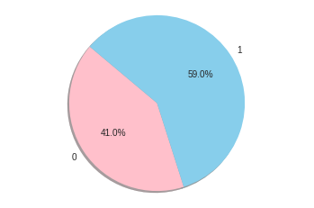

```python
labels = '0', '1'
sizes = [13307953, 19126536]
colors = ['pink', 'skyblue']
plt.pie(sizes, labels=labels, colors=colors,
        autopct='%1.1f%%', shadow=True, startangle=140)

plt.axis('equal')
plt.show()
```

#### → 전체적으로 reorder하는 빈도가 더 높다

```python
opp_final.groupby('reordered')['add_to_cart_order'].mean()
```

```
reordered
0    9.487599
1    7.560300
Name: add_to_cart_order, dtype: float64
```

add to cart가 right-skewed 되었다는 점을 감안해서 median도 확인해보기

```python
opp_final.groupby('reordered')['add_to_cart_order'].median()
```

```
reordered
0    8
1    6
Name: add_to_cart_order, dtype: int64
```

#### → 평균적으로, reorder되는 제품은 카트에 먼저 담기는 경향이 있다

#### 각 제품별로 reorder될 확률을 구해보면 test 데이터가 reorder될지 여부를 예측하는데 도움되지 않을까??!?!

## 6-3. reordered와 다른 변수들 (department, aisle, order_dow, order_hour_of_day, days_since_prior_order)간의 관계

### 1) department

```python
pd.DataFrame(opt_final.groupby("department")["reordered"].mean()).iplot(kind='scatter')
```

[interactive chart not shown]

### 2) aisle

```python
pd.DataFrame(opt_final.groupby("aisle")["reordered"].mean()).iplot(kind='scatter')
```

[interactive chart not shown]

### 3) order_dow

```python
pd.DataFrame(opt_final.groupby("order_dow")["reordered"].mean()).iplot(kind='scatter', mode='markers')
```

[interactive chart not shown]

### 4) order_hour_of_day

```python
pd.DataFrame(opt_final.groupby("order_hour_of_day")["reordered"].mean()).iplot(kind='scatter', mode='markers')
```

[interactive chart not shown]

### 5) days since prior

```python
pd.DataFrame(opt_final.groupby("days_since_prior_order")["reordered"].mean()).iplot(kind='scatter')
```

[interactive chart not shown]